# 2. Ders: Frekans Dağılımları ve Merkezi Eğilim

Çalışma soruları

← Çalışma soruları · Sunum

## Kavramları yoklama

Bir kargo firması teslimatların yüzde kaçının 24 saatten, yüzde kaçının 48 saatten kısa sürede tamamlandığını tek bir grafikten okuyabilmek istiyor. Hangi grafik en uygundur?

Çubuk çizimiPasta grafiğiHistogramBirikimli frekans eğrisi (ogive)

Doğru yanıt **Birikimli frekans eğrisi (ogive)**. “Yüzde kaçı şu değerin altında?” sorusu birikimli bir sorudur. Birikimli frekans eğrisinde her sınıfın üst sınırındaki yükseklik, o değerin altında kalan gözlemlerin oranını verir.

Grafik seçerken iki soru sorun: Değişken **kategorik mi, sayısal mı**? Ve grafikten **ne okunmak isteniyor**: sıklıkların karşılaştırılması mı, bütün içindeki paylar mı, dağılımın biçimi mi, yoksa bir değerin altında kalan oran mı?

400 hanenin aylık gıda harcamasının hangi aralıkta yoğunlaştığını, dağılımın simetrik mi çarpık mı olduğunu görmek istiyorsunuz. Hangi grafik en uygundur?

Çubuk çizimiPasta grafiğiHistogramBirikimli frekans eğrisi (ogive)

Doğru yanıt **Histogram**. Sayısal (sürekli) bir değişkenin dağılımının biçimi, merkezi, yayılımı ve tepe sayısı histogramla görülür. Dikdörtgenler bitişiktir, çünkü sınıflar sayı doğrusunda birbirini izler.

Grafik seçerken iki soru sorun: Değişken **kategorik mi, sayısal mı**? Ve grafikten **ne okunmak isteniyor**: sıklıkların karşılaştırılması mı, bütün içindeki paylar mı, dağılımın biçimi mi, yoksa bir değerin altında kalan oran mı?

Bir üniversitenin fakültelerindeki öğrenci sayılarını yan yana karşılaştırmak istiyorsunuz; hangi fakültenin hangisinden kalabalık olduğu kolayca görülmeli. Hangi grafik en uygundur?

Çubuk çizimiPasta grafiğiHistogramBirikimli frekans eğrisi (ogive)

Doğru yanıt **Çubuk çizimi**. Kategorik bir değişkenin frekanslarını karşılaştırmanın en okunaklı yolu çubuk çizimidir. Çubuk boylarını gözle karşılaştırmak, pasta dilimlerinin açılarını karşılaştırmaktan çok daha kolaydır; sıralı kategorilerde çubuklar doğal sırayla dizilir.

Grafik seçerken iki soru sorun: Değişken **kategorik mi, sayısal mı**? Ve grafikten **ne okunmak isteniyor**: sıklıkların karşılaştırılması mı, bütün içindeki paylar mı, dağılımın biçimi mi, yoksa bir değerin altında kalan oran mı?

Bir ankette 800 kişinin işe gidiş yolu (otomobil, otobüs, metro, yürüyüş, bisiklet) soruldu. Her ulaşım türünü kaç kişinin kullandığını karşılaştırmak istiyorsunuz. Hangi grafik en uygundur?

Çubuk çizimiPasta grafiğiHistogramBirikimli frekans eğrisi (ogive)

Doğru yanıt **Çubuk çizimi**. Kategorik bir değişkenin frekanslarını karşılaştırmanın en okunaklı yolu çubuk çizimidir. Çubuk boylarını gözle karşılaştırmak, pasta dilimlerinin açılarını karşılaştırmaktan çok daha kolaydır; sıralı kategorilerde çubuklar doğal sırayla dizilir.

Grafik seçerken iki soru sorun: Değişken **kategorik mi, sayısal mı**? Ve grafikten **ne okunmak isteniyor**: sıklıkların karşılaştırılması mı, bütün içindeki paylar mı, dağılımın biçimi mi, yoksa bir değerin altında kalan oran mı?

Bir otelin 300 misafirinin memnuniyeti beş düzeyde (çok kötü, …, çok iyi) soruldu. Yanıtların düzeylere göre dağılımını, düzeylerin doğal sırasını koruyarak göstermek istiyorsunuz. Hangi grafik en uygundur?

Çubuk çizimiPasta grafiğiHistogramBirikimli frekans eğrisi (ogive)

Doğru yanıt **Çubuk çizimi**. Kategorik bir değişkenin frekanslarını karşılaştırmanın en okunaklı yolu çubuk çizimidir. Çubuk boylarını gözle karşılaştırmak, pasta dilimlerinin açılarını karşılaştırmaktan çok daha kolaydır; sıralı kategorilerde çubuklar doğal sırayla dizilir.

Grafik seçerken iki soru sorun: Değişken **kategorik mi, sayısal mı**? Ve grafikten **ne okunmak isteniyor**: sıklıkların karşılaştırılması mı, bütün içindeki paylar mı, dağılımın biçimi mi, yoksa bir değerin altında kalan oran mı?

Bir ankette 800 kişinin işe gidiş yolu (otomobil, otobüs, metro, yürüyüş, bisiklet) soruldu. Her ulaşım türünü kaç kişinin kullandığını karşılaştırmak istiyorsunuz. Hangi grafik en uygundur?

Çubuk çizimiPasta grafiğiHistogramBirikimli frekans eğrisi (ogive)

Doğru yanıt **Çubuk çizimi**. Kategorik bir değişkenin frekanslarını karşılaştırmanın en okunaklı yolu çubuk çizimidir. Çubuk boylarını gözle karşılaştırmak, pasta dilimlerinin açılarını karşılaştırmaktan çok daha kolaydır; sıralı kategorilerde çubuklar doğal sırayla dizilir.

Grafik seçerken iki soru sorun: Değişken **kategorik mi, sayısal mı**? Ve grafikten **ne okunmak isteniyor**: sıklıkların karşılaştırılması mı, bütün içindeki paylar mı, dağılımın biçimi mi, yoksa bir değerin altında kalan oran mı?

Bir sınava giren 180 öğrencinin yüzde kaçının 50 puanın altında kaldığını ve öğrencilerin yarısının hangi puanın altında kaldığını grafikten okumak istiyorsunuz. Hangi grafik en uygundur?

Çubuk çizimiPasta grafiğiHistogramBirikimli frekans eğrisi (ogive)

Doğru yanıt **Birikimli frekans eğrisi (ogive)**. “Yüzde kaçı şu değerin altında?” sorusu birikimli bir sorudur. Birikimli frekans eğrisinde her sınıfın üst sınırındaki yükseklik, o değerin altında kalan gözlemlerin oranını verir.

Grafik seçerken iki soru sorun: Değişken **kategorik mi, sayısal mı**? Ve grafikten **ne okunmak isteniyor**: sıklıkların karşılaştırılması mı, bütün içindeki paylar mı, dağılımın biçimi mi, yoksa bir değerin altında kalan oran mı?

Bir belediyenin yıllık bütçesinin dört harcama kalemine (personel, yatırım, hizmet alımı, diğer) nasıl bölündüğünü, her kalemin bütündeki payını vurgulayarak göstermek istiyorsunuz. Hangi grafik en uygundur?

Çubuk çizimiPasta grafiğiHistogramBirikimli frekans eğrisi (ogive)

Doğru yanıt **Pasta grafiği**. Az sayıda kategorinin **bütün içindeki payı** soruluyorsa pasta grafiği uygundur. Dilimler bir daireyi tamamladığı için payların bütünü oluşturduğu tek bakışta görülür. Yine de dilimler birbirine yakınsa çubuk çizimi karşılaştırmayı kolaylaştırır.

Grafik seçerken iki soru sorun: Değişken **kategorik mi, sayısal mı**? Ve grafikten **ne okunmak isteniyor**: sıklıkların karşılaştırılması mı, bütün içindeki paylar mı, dağılımın biçimi mi, yoksa bir değerin altında kalan oran mı?

Aşağıdaki histogram şu veriye aittir: Bir makinenin doldurduğu 400 paketin ağırlığı (gram).

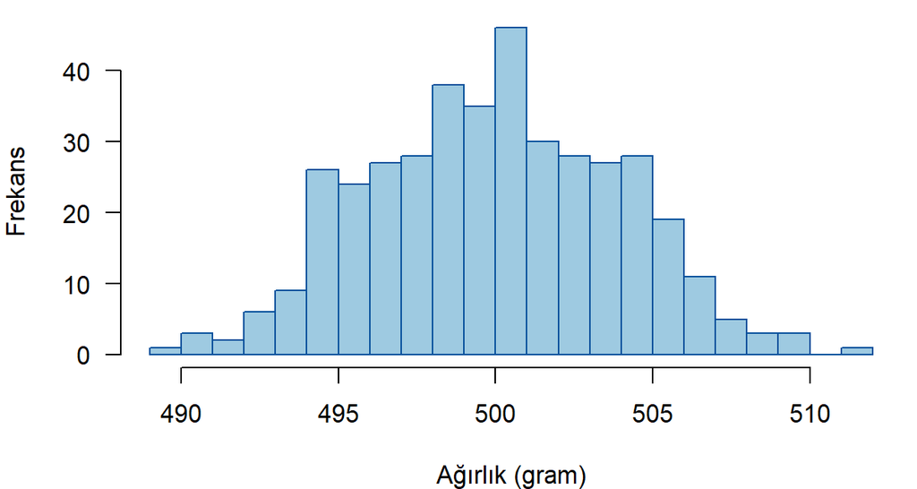

- Dağılımın biçimi:
- Ortalama ile medyan:

**Simetrik, tek tepeli.** Gözlemler bir merkez etrafında iki yana benzer biçimde dağılmış, tek tepe var.

**Ortalama ile medyan birbirine yakındır.** Bu veride ortalama 500.0, medyan 500.0. Simetrik dağılımda iki kuyruk birbirini dengeler.

Aşağıdaki histogram şu veriye aittir: Bir makinenin doldurduğu 400 paketin ağırlığı (gram).

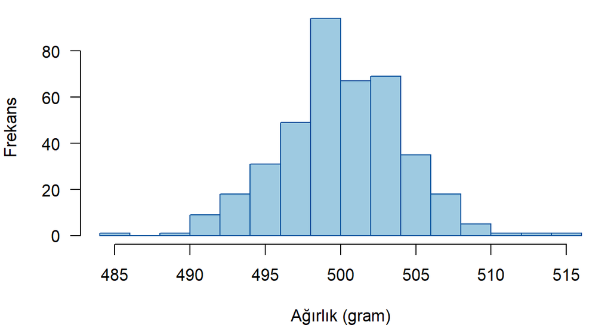

- Dağılımın biçimi:
- Ortalama ile medyan:

**Simetrik, tek tepeli.** Gözlemler bir merkez etrafında iki yana benzer biçimde dağılmış, tek tepe var.

**Ortalama ile medyan birbirine yakındır.** Bu veride ortalama 500.0, medyan 499.9. Simetrik dağılımda iki kuyruk birbirini dengeler.

Aşağıdaki histogram şu veriye aittir: Bir kentte 400 kiracı hanenin aylık kira ödemesi (TL).

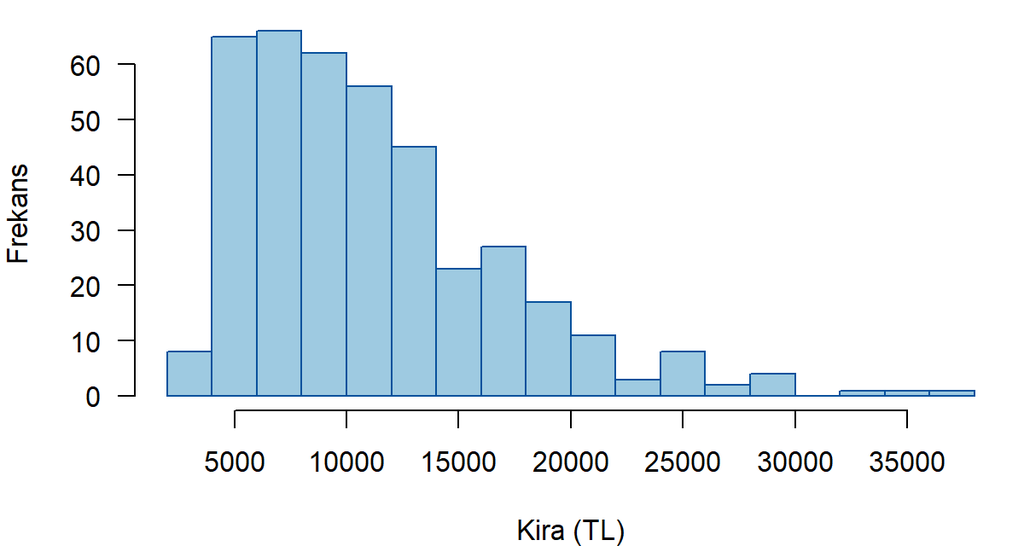

- Dağılımın biçimi:
- Ortalama ile medyan:

**Sağa çarpık.** Gözlemlerin çoğu solda toplanmış, uzun kuyruk sağda: az sayıda hane çok yüksek kira ödüyor.

**Ortalama medyandan belirgin biçimde büyüktür.** Bu veride ortalama 11159.9, medyan 9980.7. Uzun sağ kuyruktaki yüksek değerler ortalamayı yukarı çeker; medyan bu değerlerden çok az etkilenir.

Aşağıdaki histogram şu veriye aittir: Bir kentte 400 kiracı hanenin aylık kira ödemesi (TL).

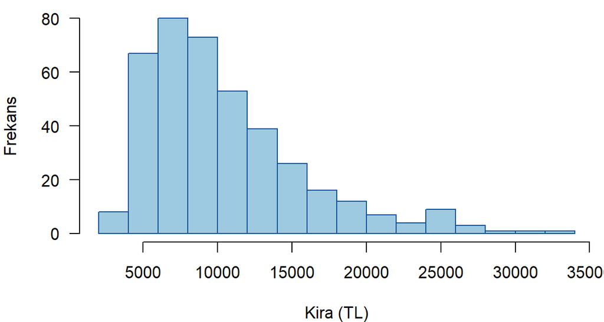

- Dağılımın biçimi:
- Ortalama ile medyan:

**Sağa çarpık.** Gözlemlerin çoğu solda toplanmış, uzun kuyruk sağda: az sayıda hane çok yüksek kira ödüyor.

**Ortalama medyandan belirgin biçimde büyüktür.** Bu veride ortalama 10471.6, medyan 9097.9. Uzun sağ kuyruktaki yüksek değerler ortalamayı yukarı çeker; medyan bu değerlerden çok az etkilenir.

Aşağıdaki histogram şu veriye aittir: Bir kentte 400 kiracı hanenin aylık kira ödemesi (TL).

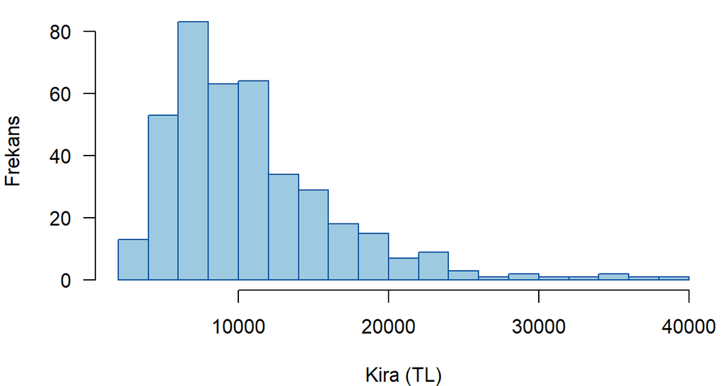

- Dağılımın biçimi:
- Ortalama ile medyan:

**Sağa çarpık.** Gözlemlerin çoğu solda toplanmış, uzun kuyruk sağda: az sayıda hane çok yüksek kira ödüyor.

**Ortalama medyandan belirgin biçimde büyüktür.** Bu veride ortalama 10831.4, medyan 9607.6. Uzun sağ kuyruktaki yüksek değerler ortalamayı yukarı çeker; medyan bu değerlerden çok az etkilenir.

Aşağıdaki histogram şu veriye aittir: Kolay bir sınava giren 400 öğrencinin notları.

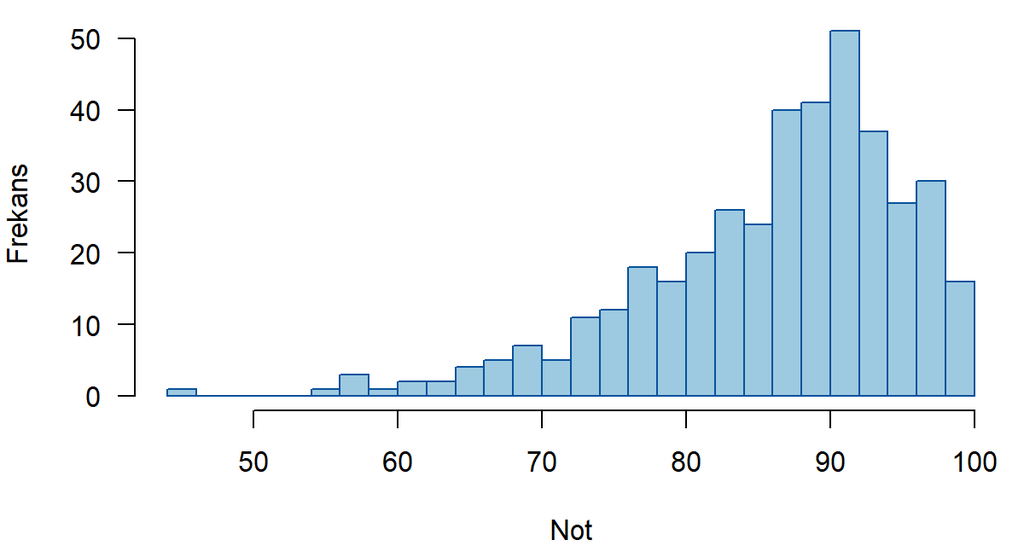

- Dağılımın biçimi:
- Ortalama ile medyan:

**Sola çarpık.** Gözlemlerin çoğu sağda toplanmış, uzun kuyruk solda: az sayıda öğrenci çok düşük not almış.

**Ortalama medyandan belirgin biçimde küçüktür.** Bu veride ortalama 86.1, medyan 88.2. Uzun sol kuyruktaki düşük değerler ortalamayı aşağı çeker; medyan sıralamaya dayandığı için bu değerlerden çok az etkilenir.

Aşağıdaki histogram şu veriye aittir: Bir kafeye bir günde gelen 400 müşterinin geliş saati.

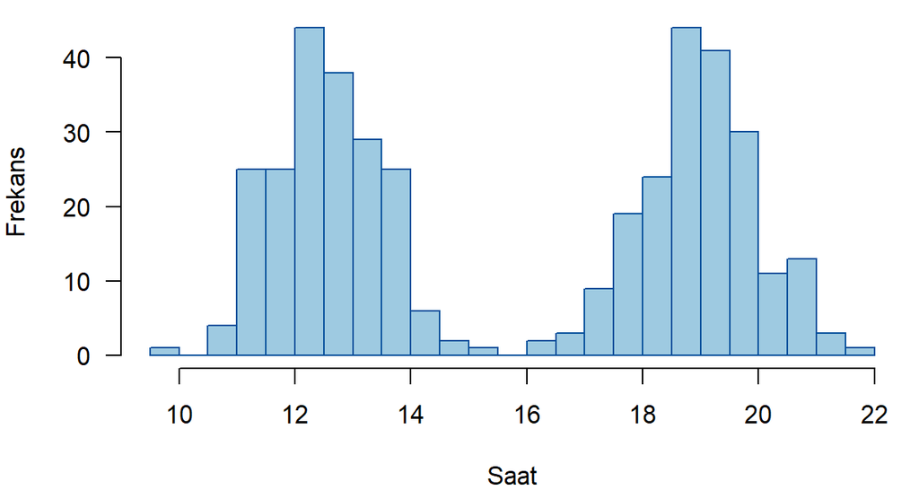

- Dağılımın biçimi:
- Ortalama ile medyan:

**İki tepeli.** İki ayrı tepe var: öğle ve akşam saatlerinde yoğunlaşan iki müşteri grubu bir arada.

**Ortalama ile medyan birbirine yakındır.** Bu veride ortalama 15.8, medyan 15.8. İki tepe simetrik yerleştiği için ortalama ile medyan yakın. Ama ikisi de iki tepenin **arasına**, müşterinin en az geldiği saatlere düşüyor: iki tepeli bir dağılımda tek bir merkez ölçüsü tipik gözlemi anlatmaz.

Aşağıdaki histogram şu veriye aittir: Bir kentte 400 kiracı hanenin aylık kira ödemesi (TL).

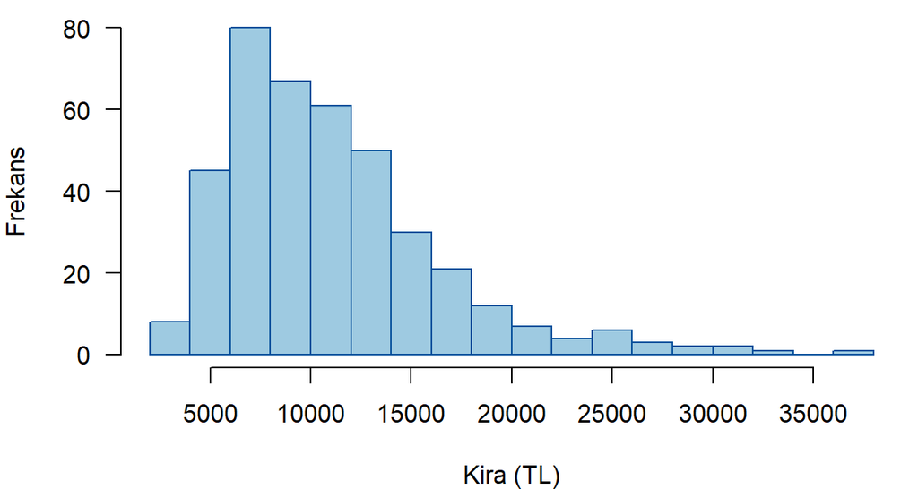

- Dağılımın biçimi:
- Ortalama ile medyan:

**Sağa çarpık.** Gözlemlerin çoğu solda toplanmış, uzun kuyruk sağda: az sayıda hane çok yüksek kira ödüyor.

**Ortalama medyandan belirgin biçimde büyüktür.** Bu veride ortalama 11043.1, medyan 10007.8. Uzun sağ kuyruktaki yüksek değerler ortalamayı yukarı çeker; medyan bu değerlerden çok az etkilenir.

Bir ayakkabı mağazası yeni sezon için stok planlıyor ve en çok hangi numaradan sipariş vermesi gerektiğini bilmek istiyor. Geçen sezonun satışlarını özetlemek için hangi ölçü en kullanışlıdır?

OrtalamaMedyanModGeometrik ortalama

Doğru yanıt **Mod**. Mağazanın sorusu “en çok satılan numara hangisi?” sorusudur; bu mod’dur. 40.3 numara ortalamasının ya da medyanın stok planında karşılığı yoktur.

| Veri | Uygun ölçü |
| --- | --- |
| Simetrik, uç değer yok | Ortalama |
| Çarpık ya da uç değer var | Medyan |
| Nominal (kategorik) | Mod |
| Büyüme ve getiri oranları | Geometrik ortalama |

Bir marketin müşterilerine en çok tercih ettikleri kahve markası sorulmuştur. Yanıtlar marka adlarından oluşmaktadır. Bu veriyi özetlemek için hangi ölçü kullanılabilir?

OrtalamaMedyanModGeometrik ortalama

Doğru yanıt **Mod**. Veri nominaldir. Marka adları ne toplanabilir ne sıralanabilir, dolayısıyla ortalama ve medyan tanımsızdır. En sık görülen kategoriyi veren mod tek seçenektir.

| Veri | Uygun ölçü |
| --- | --- |
| Simetrik, uç değer yok | Ortalama |
| Çarpık ya da uç değer var | Medyan |
| Nominal (kategorik) | Mod |
| Büyüme ve getiri oranları | Geometrik ortalama |

Bir işletme, bir ayda şubelerine dağıttığı toplam sipariş miktarını şube sayısından hareketle bulmak istiyor; şube başına tipik bir değer ile şube sayısını çarpınca toplamı elde etmesi gerekiyor. Hangi ölçü kullanılmalıdır?

OrtalamaMedyanModGeometrik ortalama

Doğru yanıt **Ortalama**. Ortalama ile gözlem sayısının çarpımı toplamı verir: $n\bar{x} = \sum x_i$. Medyan ya da mod için böyle bir özellik yoktur.

| Veri | Uygun ölçü |
| --- | --- |
| Simetrik, uç değer yok | Ortalama |
| Çarpık ya da uç değer var | Medyan |
| Nominal (kategorik) | Mod |
| Büyüme ve getiri oranları | Geometrik ortalama |

Bir işletme, bir ayda şubelerine dağıttığı toplam sipariş miktarını şube sayısından hareketle bulmak istiyor; şube başına tipik bir değer ile şube sayısını çarpınca toplamı elde etmesi gerekiyor. Hangi ölçü kullanılmalıdır?

OrtalamaMedyanModGeometrik ortalama

Doğru yanıt **Ortalama**. Ortalama ile gözlem sayısının çarpımı toplamı verir: $n\bar{x} = \sum x_i$. Medyan ya da mod için böyle bir özellik yoktur.

| Veri | Uygun ölçü |
| --- | --- |
| Simetrik, uç değer yok | Ortalama |
| Çarpık ya da uç değer var | Medyan |
| Nominal (kategorik) | Mod |
| Büyüme ve getiri oranları | Geometrik ortalama |

Bir mahalledeki hanelerin yıllık gelirleri incelenmektedir. Hanelerin çoğu birbirine yakın gelirlere sahiptir, ancak mahallede geliri diğerlerinin yüzlerce katı olan üç hane bulunmaktadır. Tipik hane gelirini betimlemek için hangi ölçü kullanılmalıdır?

OrtalamaMedyanModGeometrik ortalama

Doğru yanıt **Medyan**. Üç aşırı yüksek gelir ortalamayı yukarı çeker ve ortalama artık tipik haneyi temsil etmez. Medyan sıralamaya dayandığı için uç değerlerden çok az etkilenir.

| Veri | Uygun ölçü |
| --- | --- |
| Simetrik, uç değer yok | Ortalama |
| Çarpık ya da uç değer var | Medyan |
| Nominal (kategorik) | Mod |
| Büyüme ve getiri oranları | Geometrik ortalama |

Bir ilin nüfusu son on yılda her yıl farklı bir oranda artmıştır. Yıllık ortalama nüfus artış hızını bulmak için hangi ölçü uygundur?

OrtalamaMedyanModGeometrik ortalama

Doğru yanıt **Geometrik ortalama**. Her yılın artışı bir önceki yılın nüfusu üzerine eklenir, yani oranlar çarpılarak birikir. Ortalama artış hızı geometrik ortalamadır: $\left(\prod (1 + g_i)\right)^{1/n} - 1$.

| Veri | Uygun ölçü |
| --- | --- |
| Simetrik, uç değer yok | Ortalama |
| Çarpık ya da uç değer var | Medyan |
| Nominal (kategorik) | Mod |
| Büyüme ve getiri oranları | Geometrik ortalama |

Bir ilin nüfusu son on yılda her yıl farklı bir oranda artmıştır. Yıllık ortalama nüfus artış hızını bulmak için hangi ölçü uygundur?

OrtalamaMedyanModGeometrik ortalama

Doğru yanıt **Geometrik ortalama**. Her yılın artışı bir önceki yılın nüfusu üzerine eklenir, yani oranlar çarpılarak birikir. Ortalama artış hızı geometrik ortalamadır: $\left(\prod (1 + g_i)\right)^{1/n} - 1$.

| Veri | Uygun ölçü |
| --- | --- |
| Simetrik, uç değer yok | Ortalama |
| Çarpık ya da uç değer var | Medyan |
| Nominal (kategorik) | Mod |
| Büyüme ve getiri oranları | Geometrik ortalama |

Bir işletme, bir ayda şubelerine dağıttığı toplam sipariş miktarını şube sayısından hareketle bulmak istiyor; şube başına tipik bir değer ile şube sayısını çarpınca toplamı elde etmesi gerekiyor. Hangi ölçü kullanılmalıdır?

OrtalamaMedyanModGeometrik ortalama

Doğru yanıt **Ortalama**. Ortalama ile gözlem sayısının çarpımı toplamı verir: $n\bar{x} = \sum x_i$. Medyan ya da mod için böyle bir özellik yoktur.

| Veri | Uygun ölçü |
| --- | --- |
| Simetrik, uç değer yok | Ortalama |
| Çarpık ya da uç değer var | Medyan |
| Nominal (kategorik) | Mod |
| Büyüme ve getiri oranları | Geometrik ortalama |

Bir dükkânın aylık cirosu bir ay %50 azalıyor, ertesi ay %50 artıyor. İki ayın sonunda değer başlangıç düzeyine göre nasıldır?

Artışın mı azalışın mı önce geldiğine bağlıdırBaşlangıç düzeyinden yüksektirBaşlangıç düzeyine eşittirBaşlangıç düzeyinden düşüktür

Doğru yanıt **Başlangıç düzeyinden düşüktür**. Oranlar toplanarak değil çarpılarak birikir. Başlangıç değeri 100 olsun:

$$100 \times 0.50 \times 1.50 = 75.00$$

Değer başlangıçtan %25.00 **düşüktür**. Genel olarak $(1 + r)(1 - r) = 1 - r^2 < 1$ olduğundan aynı oranda artış ve azalış hep kayıpla sonuçlanır. Çarpmada sıra önemli olmadığı için artışın ya da azalışın önce gelmesi sonucu değiştirmez.

Aritmetik ortalama $(50 - 50)/2 = 0$ der ve yanıltır. Dönem başını dönem sonuna bağlayan ortalama oran geometrik ortalamadır: $\sqrt{0.75} - 1 = -0.1340$, yani dönem başına ortalama %13.40 düşüş.

Bir dükkânın aylık cirosu bir ay %50 azalıyor, ertesi ay %50 artıyor. İki ayın sonunda değer başlangıç düzeyine göre nasıldır?

Başlangıç düzeyinden düşüktürArtışın mı azalışın mı önce geldiğine bağlıdırBaşlangıç düzeyinden yüksektirBaşlangıç düzeyine eşittir

Doğru yanıt **Başlangıç düzeyinden düşüktür**. Oranlar toplanarak değil çarpılarak birikir. Başlangıç değeri 100 olsun:

$$100 \times 0.50 \times 1.50 = 75.00$$

Değer başlangıçtan %25.00 **düşüktür**. Genel olarak $(1 + r)(1 - r) = 1 - r^2 < 1$ olduğundan aynı oranda artış ve azalış hep kayıpla sonuçlanır. Çarpmada sıra önemli olmadığı için artışın ya da azalışın önce gelmesi sonucu değiştirmez.

Aritmetik ortalama $(50 - 50)/2 = 0$ der ve yanıltır. Dönem başını dönem sonuna bağlayan ortalama oran geometrik ortalamadır: $\sqrt{0.75} - 1 = -0.1340$, yani dönem başına ortalama %13.40 düşüş.

Bir dükkânın aylık cirosu bir ay %10 azalıyor, ertesi ay %10 artıyor. İki ayın sonunda değer başlangıç düzeyine göre nasıldır?

Artışın mı azalışın mı önce geldiğine bağlıdırBaşlangıç düzeyinden yüksektirBaşlangıç düzeyinden düşüktürBaşlangıç düzeyine eşittir

Doğru yanıt **Başlangıç düzeyinden düşüktür**. Oranlar toplanarak değil çarpılarak birikir. Başlangıç değeri 100 olsun:

$$100 \times 0.90 \times 1.10 = 99.00$$

Değer başlangıçtan %1.00 **düşüktür**. Genel olarak $(1 + r)(1 - r) = 1 - r^2 < 1$ olduğundan aynı oranda artış ve azalış hep kayıpla sonuçlanır. Çarpmada sıra önemli olmadığı için artışın ya da azalışın önce gelmesi sonucu değiştirmez.

Aritmetik ortalama $(10 - 10)/2 = 0$ der ve yanıltır. Dönem başını dönem sonuna bağlayan ortalama oran geometrik ortalamadır: $\sqrt{0.99} - 1 = -0.0050$, yani dönem başına ortalama %0.50 düşüş.

Bir hisse senedinin fiyatı birinci yıl %10 artıyor, ikinci yıl %10 azalıyor. İki yılın sonunda değer başlangıç düzeyine göre nasıldır?

Başlangıç düzeyine eşittirBaşlangıç düzeyinden düşüktürArtışın mı azalışın mı önce geldiğine bağlıdırBaşlangıç düzeyinden yüksektir

Doğru yanıt **Başlangıç düzeyinden düşüktür**. Oranlar toplanarak değil çarpılarak birikir. Başlangıç değeri 100 olsun:

$$100 \times 1.10 \times 0.90 = 99.00$$

Değer başlangıçtan %1.00 **düşüktür**. Genel olarak $(1 + r)(1 - r) = 1 - r^2 < 1$ olduğundan aynı oranda artış ve azalış hep kayıpla sonuçlanır. Çarpmada sıra önemli olmadığı için artışın ya da azalışın önce gelmesi sonucu değiştirmez.

Aritmetik ortalama $(10 - 10)/2 = 0$ der ve yanıltır. Dönem başını dönem sonuna bağlayan ortalama oran geometrik ortalamadır: $\sqrt{0.99} - 1 = -0.0050$, yani dönem başına ortalama %0.50 düşüş.

Bir dükkânın aylık cirosu bir ay %20 azalıyor, ertesi ay %20 artıyor. İki ayın sonunda değer başlangıç düzeyine göre nasıldır?

Başlangıç düzeyinden düşüktürArtışın mı azalışın mı önce geldiğine bağlıdırBaşlangıç düzeyine eşittirBaşlangıç düzeyinden yüksektir

Doğru yanıt **Başlangıç düzeyinden düşüktür**. Oranlar toplanarak değil çarpılarak birikir. Başlangıç değeri 100 olsun:

$$100 \times 0.80 \times 1.20 = 96.00$$

Değer başlangıçtan %4.00 **düşüktür**. Genel olarak $(1 + r)(1 - r) = 1 - r^2 < 1$ olduğundan aynı oranda artış ve azalış hep kayıpla sonuçlanır. Çarpmada sıra önemli olmadığı için artışın ya da azalışın önce gelmesi sonucu değiştirmez.

Aritmetik ortalama $(20 - 20)/2 = 0$ der ve yanıltır. Dönem başını dönem sonuna bağlayan ortalama oran geometrik ortalamadır: $\sqrt{0.96} - 1 = -0.0202$, yani dönem başına ortalama %2.02 düşüş.

Bir dükkânın aylık cirosu bir ay %25 artıyor, ertesi ay %25 azalıyor. İki ayın sonunda değer başlangıç düzeyine göre nasıldır?

Artışın mı azalışın mı önce geldiğine bağlıdırBaşlangıç düzeyinden yüksektirBaşlangıç düzeyine eşittirBaşlangıç düzeyinden düşüktür

Doğru yanıt **Başlangıç düzeyinden düşüktür**. Oranlar toplanarak değil çarpılarak birikir. Başlangıç değeri 100 olsun:

$$100 \times 1.25 \times 0.75 = 93.75$$

Değer başlangıçtan %6.25 **düşüktür**. Genel olarak $(1 + r)(1 - r) = 1 - r^2 < 1$ olduğundan aynı oranda artış ve azalış hep kayıpla sonuçlanır. Çarpmada sıra önemli olmadığı için artışın ya da azalışın önce gelmesi sonucu değiştirmez.

Aritmetik ortalama $(25 - 25)/2 = 0$ der ve yanıltır. Dönem başını dönem sonuna bağlayan ortalama oran geometrik ortalamadır: $\sqrt{0.94} - 1 = -0.0318$, yani dönem başına ortalama %3.18 düşüş.

Bir ürünün fiyatı ocakta %40 artıyor, şubatta %40 azalıyor. Şubat sonunda değer başlangıç düzeyine göre nasıldır?

Başlangıç düzeyine eşittirArtışın mı azalışın mı önce geldiğine bağlıdırBaşlangıç düzeyinden düşüktürBaşlangıç düzeyinden yüksektir

Doğru yanıt **Başlangıç düzeyinden düşüktür**. Oranlar toplanarak değil çarpılarak birikir. Başlangıç değeri 100 olsun:

$$100 \times 1.40 \times 0.60 = 84.00$$

Değer başlangıçtan %16.00 **düşüktür**. Genel olarak $(1 + r)(1 - r) = 1 - r^2 < 1$ olduğundan aynı oranda artış ve azalış hep kayıpla sonuçlanır. Çarpmada sıra önemli olmadığı için artışın ya da azalışın önce gelmesi sonucu değiştirmez.

Aritmetik ortalama $(40 - 40)/2 = 0$ der ve yanıltır. Dönem başını dönem sonuna bağlayan ortalama oran geometrik ortalamadır: $\sqrt{0.84} - 1 = -0.0835$, yani dönem başına ortalama %8.35 düşüş.

Bir ürünün fiyatı ocakta %10 azalıyor, şubatta %10 artıyor. Şubat sonunda değer başlangıç düzeyine göre nasıldır?

Artışın mı azalışın mı önce geldiğine bağlıdırBaşlangıç düzeyinden yüksektirBaşlangıç düzeyine eşittirBaşlangıç düzeyinden düşüktür

Doğru yanıt **Başlangıç düzeyinden düşüktür**. Oranlar toplanarak değil çarpılarak birikir. Başlangıç değeri 100 olsun:

$$100 \times 0.90 \times 1.10 = 99.00$$

Değer başlangıçtan %1.00 **düşüktür**. Genel olarak $(1 + r)(1 - r) = 1 - r^2 < 1$ olduğundan aynı oranda artış ve azalış hep kayıpla sonuçlanır. Çarpmada sıra önemli olmadığı için artışın ya da azalışın önce gelmesi sonucu değiştirmez.

Aritmetik ortalama $(10 - 10)/2 = 0$ der ve yanıltır. Dönem başını dönem sonuna bağlayan ortalama oran geometrik ortalamadır: $\sqrt{0.99} - 1 = -0.0050$, yani dönem başına ortalama %0.50 düşüş.

## Uygulama ve yorum

### Frekans tabloları ve grafikler

Bir kurstaki katılımcıların yaşı aşağıda verilmiştir ($n = 18$).

$$44,\ 43,\ 38,\ 40,\ 45,\ 37,\ 28,\ 20,\ 34,\ 20,\ 25,\ 33,\ 37,\ 53,\ 30,\ 25,\ 17,\ 37$$

Genişliği 10 olan sınıflarla frekans tablosu kurulacaktır. Sınıflar $[a, b)$ biçimindedir: alt sınır **dahil**, üst sınır **hariç**.

| Sınıf | [15, 25) | [25, 35) | [35, 45) | [45, 55) |
| --- | --- | --- | --- | --- |
| Frekans | 3 | ? | ? | 2 |

- [25, 35) sınıfının frekansı:
- [35, 45) sınıfının göreli frekansı (iki ondalık):
- [35, 45) sınıfına kadar (bu sınıf dahil) birikimli yüzde:

Önce veriyi sıralamak saymayı kolaylaştırır:

$$17,\ 20,\ 20,\ 25,\ 25,\ 28,\ 30,\ 33,\ 34,\ 37,\ 37,\ 37,\ 38,\ 40,\ 43,\ 44,\ 45,\ 53$$

| Sınıf | Frekans | Göreli frekans | Birikimli frekans | Birikimli yüzde |
| --- | --- | --- | --- | --- |
| [15, 25) | 3 | 0.17 | 3 | 16.67 |
| [25, 35) | 6 | 0.33 | 9 | 50.00 |
| [35, 45) | 7 | 0.39 | 16 | 88.89 |
| [45, 55) | 2 | 0.11 | 18 | 100.00 |
| **Toplam** | **18** | **1.00** |  |  |

**Dikkat:** Veride 25 değeri var. Bu değer bir sınıfın üst sınırı, bir sonrakinin alt sınırıdır; alt sınır dahil olduğu için **[25, 35)** sınıfına sayılır. Sınıflar hem kapsayıcı (her gözlem bir sınıfa) hem ayrık (hiçbir gözlem iki sınıfa) olmalıdır.

Göreli frekans = frekans / $n$ = 7 / 18 = 0.39. Birikimli yüzde = (3 + 6 + 7) / 18 × 100 = 88.89. Denetim: frekansların toplamı $n$, göreli frekansların toplamı 1 olmalıdır.

Bir mağazada günlük satılan ürün adedi aşağıda verilmiştir ($n = 20$).

$$37,\ 21,\ 37,\ 28,\ 21,\ 25,\ 29,\ 20,\ 21,\ 32,\ 24,\ 22,\ 39,\ 38,\ 24,\ 35,\ 31,\ 29,\ 29,\ 30$$

Genişliği 5 olan sınıflarla frekans tablosu kurulacaktır. Sınıflar $[a, b)$ biçimindedir: alt sınır **dahil**, üst sınır **hariç**.

| Sınıf | [20, 25) | [25, 30) | [30, 35) | [35, 40) |
| --- | --- | --- | --- | --- |
| Frekans | 7 | ? | ? | 5 |

- [25, 30) sınıfının frekansı:
- [30, 35) sınıfının göreli frekansı (iki ondalık):
- [30, 35) sınıfına kadar (bu sınıf dahil) birikimli yüzde:

Önce veriyi sıralamak saymayı kolaylaştırır:

$$20,\ 21,\ 21,\ 21,\ 22,\ 24,\ 24,\ 25,\ 28,\ 29,\ 29,\ 29,\ 30,\ 31,\ 32,\ 35,\ 37,\ 37,\ 38,\ 39$$

| Sınıf | Frekans | Göreli frekans | Birikimli frekans | Birikimli yüzde |
| --- | --- | --- | --- | --- |
| [20, 25) | 7 | 0.35 | 7 | 35.00 |
| [25, 30) | 5 | 0.25 | 12 | 60.00 |
| [30, 35) | 3 | 0.15 | 15 | 75.00 |
| [35, 40) | 5 | 0.25 | 20 | 100.00 |
| **Toplam** | **20** | **1.00** |  |  |

**Dikkat:** Veride 25 değeri var. Bu değer bir sınıfın üst sınırı, bir sonrakinin alt sınırıdır; alt sınır dahil olduğu için **[25, 30)** sınıfına sayılır. Sınıflar hem kapsayıcı (her gözlem bir sınıfa) hem ayrık (hiçbir gözlem iki sınıfa) olmalıdır.

Göreli frekans = frekans / $n$ = 3 / 20 = 0.15. Birikimli yüzde = (7 + 5 + 3) / 20 × 100 = 75.00. Denetim: frekansların toplamı $n$, göreli frekansların toplamı 1 olmalıdır.

Bir kafede rassal seçilen müşterilerin masada geçirdiği süre (dakika) aşağıda verilmiştir ($n = 18$).

$$36,\ 18,\ 26,\ 12,\ 30,\ 41,\ 39,\ 30,\ 26,\ 10,\ 20,\ 26,\ 22,\ 15,\ 24,\ 30,\ 42,\ 47$$

Genişliği 10 olan sınıflarla frekans tablosu kurulacaktır. Sınıflar $[a, b)$ biçimindedir: alt sınır **dahil**, üst sınır **hariç**.

| Sınıf | [10, 20) | [20, 30) | [30, 40) | [40, 50) |
| --- | --- | --- | --- | --- |
| Frekans | 4 | ? | ? | 3 |

- [20, 30) sınıfının frekansı:
- [30, 40) sınıfının göreli frekansı (iki ondalık):
- [30, 40) sınıfına kadar (bu sınıf dahil) birikimli yüzde:

Önce veriyi sıralamak saymayı kolaylaştırır:

$$10,\ 12,\ 15,\ 18,\ 20,\ 22,\ 24,\ 26,\ 26,\ 26,\ 30,\ 30,\ 30,\ 36,\ 39,\ 41,\ 42,\ 47$$

| Sınıf | Frekans | Göreli frekans | Birikimli frekans | Birikimli yüzde |
| --- | --- | --- | --- | --- |
| [10, 20) | 4 | 0.22 | 4 | 22.22 |
| [20, 30) | 6 | 0.33 | 10 | 55.56 |
| [30, 40) | 5 | 0.28 | 15 | 83.33 |
| [40, 50) | 3 | 0.17 | 18 | 100.00 |
| **Toplam** | **18** | **1.00** |  |  |

**Dikkat:** Veride 30 değeri var. Bu değer bir sınıfın üst sınırı, bir sonrakinin alt sınırıdır; alt sınır dahil olduğu için **[30, 40)** sınıfına sayılır. Sınıflar hem kapsayıcı (her gözlem bir sınıfa) hem ayrık (hiçbir gözlem iki sınıfa) olmalıdır.

Göreli frekans = frekans / $n$ = 5 / 18 = 0.28. Birikimli yüzde = (4 + 6 + 5) / 18 × 100 = 83.33. Denetim: frekansların toplamı $n$, göreli frekansların toplamı 1 olmalıdır.

Bir kurstaki katılımcıların yaşı aşağıda verilmiştir ($n = 16$).

$$15,\ 32,\ 33,\ 24,\ 37,\ 54,\ 16,\ 54,\ 24,\ 35,\ 25,\ 46,\ 33,\ 47,\ 21,\ 20$$

Genişliği 10 olan sınıflarla frekans tablosu kurulacaktır. Sınıflar $[a, b)$ biçimindedir: alt sınır **dahil**, üst sınır **hariç**.

| Sınıf | [15, 25) | [25, 35) | [35, 45) | [45, 55) |
| --- | --- | --- | --- | --- |
| Frekans | 6 | ? | ? | 4 |

- [25, 35) sınıfının frekansı:
- [35, 45) sınıfının göreli frekansı (iki ondalık):
- [35, 45) sınıfına kadar (bu sınıf dahil) birikimli yüzde:

Önce veriyi sıralamak saymayı kolaylaştırır:

$$15,\ 16,\ 20,\ 21,\ 24,\ 24,\ 25,\ 32,\ 33,\ 33,\ 35,\ 37,\ 46,\ 47,\ 54,\ 54$$

| Sınıf | Frekans | Göreli frekans | Birikimli frekans | Birikimli yüzde |
| --- | --- | --- | --- | --- |
| [15, 25) | 6 | 0.38 | 6 | 37.50 |
| [25, 35) | 4 | 0.25 | 10 | 62.50 |
| [35, 45) | 2 | 0.12 | 12 | 75.00 |
| [45, 55) | 4 | 0.25 | 16 | 100.00 |
| **Toplam** | **16** | **1.00** |  |  |

**Dikkat:** Veride 35 değeri var. Bu değer bir sınıfın üst sınırı, bir sonrakinin alt sınırıdır; alt sınır dahil olduğu için **[35, 45)** sınıfına sayılır. Sınıflar hem kapsayıcı (her gözlem bir sınıfa) hem ayrık (hiçbir gözlem iki sınıfa) olmalıdır.

Göreli frekans = frekans / $n$ = 2 / 16 = 0.12. Birikimli yüzde = (6 + 4 + 2) / 16 × 100 = 75.00. Denetim: frekansların toplamı $n$, göreli frekansların toplamı 1 olmalıdır.

Aşağıdaki dal-yaprak çizimi şu veriye aittir: Bir ilçede ilana çıkan dairelerin büyüklüğü (metrekare). Okuma: `8 | 0` = 80.

```
5 | 1
6 | 4 7 7 9
7 | 0 3 6 6 6 7
8 | 0 2 2 2 4 5 7 7 8
9 | 0
```

- Gözlem sayısı:
- En büyük değer:
- 80 değerinin altında kalan gözlem sayısı:
- Medyan:

Her yaprak bir gözlemdir, satırdaki yaprak sayısı o daldaki gözlem sayısıdır.

| Dal | 5 | 6 | 7 | 8 | 9 |
| --- | --- | --- | --- | --- | --- |
| Yaprak sayısı | 1 | 4 | 6 | 9 | 1 |
| Birikimli | 1 | 5 | 11 | 20 | 21 |

- $n = 1 + 4 + 6 + 9 + 1 = 21$
- En büyük değer son satırın son yaprağıdır: **90**.
- 80 değerinin altı, 8 dalından önceki satırlardır: $1 + 4 + 6 = 11$
- $n = 21$ tek olduğu için medyan sıralı verideki $(n + 1)/2 = 11$. gözlemdir. Birikimli sayılara göre bu gözlem 7 dalındadır ve o satırın 6. yaprağıdır: **77**.

Dal-yaprak çizimi veriyi sıralanmış olarak verir: 51, 64, 67, 67, 69, 70, 73, 76, 76, 76, 77, 80, 82, 82, 82, 84, 85, 87, 87, 88, 90.

Aşağıdaki dal-yaprak çizimi şu veriye aittir: Bir sınıftaki öğrencilerin istatistik sınavından aldığı notlar. Okuma: `6 | 4` = 64.

```
3 | 2
4 | 7
5 | 4 5
6 | 0 2 2 3 4 6
7 | 0 5
8 | 1 4
9 | 1
```

- Gözlem sayısı:
- En büyük değer:
- 60 değerinin altında kalan gözlem sayısı:
- Medyan:

Her yaprak bir gözlemdir, satırdaki yaprak sayısı o daldaki gözlem sayısıdır.

| Dal | 3 | 4 | 5 | 6 | 7 | 8 | 9 |
| --- | --- | --- | --- | --- | --- | --- | --- |
| Yaprak sayısı | 1 | 1 | 2 | 6 | 2 | 2 | 1 |
| Birikimli | 1 | 2 | 4 | 10 | 12 | 14 | 15 |

- $n = 1 + 1 + 2 + 6 + 2 + 2 + 1 = 15$
- En büyük değer son satırın son yaprağıdır: **91**.
- 60 değerinin altı, 6 dalından önceki satırlardır: $1 + 1 + 2 = 4$
- $n = 15$ tek olduğu için medyan sıralı verideki $(n + 1)/2 = 8$. gözlemdir. Birikimli sayılara göre bu gözlem 6 dalındadır ve o satırın 4. yaprağıdır: **63**.

Dal-yaprak çizimi veriyi sıralanmış olarak verir: 32, 47, 54, 55, 60, 62, 62, 63, 64, 66, 70, 75, 81, 84, 91.

Aşağıdaki dal-yaprak çizimi şu veriye aittir: Bir sınıftaki öğrencilerin istatistik sınavından aldığı notlar. Okuma: `6 | 6` = 66.

```
3 | 4
4 | 1 5
5 | 2 4 8 8 9
6 | 1 3 6 6 7 7 9
7 | 0 2 6 9
8 | 0 3
```

- Gözlem sayısı:
- En büyük değer:
- 50 değerinin altında kalan gözlem sayısı:
- Medyan:

Her yaprak bir gözlemdir, satırdaki yaprak sayısı o daldaki gözlem sayısıdır.

| Dal | 3 | 4 | 5 | 6 | 7 | 8 |
| --- | --- | --- | --- | --- | --- | --- |
| Yaprak sayısı | 1 | 2 | 5 | 7 | 4 | 2 |
| Birikimli | 1 | 3 | 8 | 15 | 19 | 21 |

- $n = 1 + 2 + 5 + 7 + 4 + 2 = 21$
- En büyük değer son satırın son yaprağıdır: **83**.
- 50 değerinin altı, 5 dalından önceki satırlardır: $1 + 2 = 3$
- $n = 21$ tek olduğu için medyan sıralı verideki $(n + 1)/2 = 11$. gözlemdir. Birikimli sayılara göre bu gözlem 6 dalındadır ve o satırın 3. yaprağıdır: **66**.

Dal-yaprak çizimi veriyi sıralanmış olarak verir: 34, 41, 45, 52, 54, 58, 58, 59, 61, 63, 66, 66, 67, 67, 69, 70, 72, 76, 79, 80, 83.

Aşağıdaki dal-yaprak çizimi şu veriye aittir: Bir ilçede ilana çıkan dairelerin büyüklüğü (metrekare). Okuma: `7 | 6` = 76.

```
6 | 0 4 8 9
7 | 0 2 3 4 5 5 5 6 7
8 | 3 4 6 6 8
9 | 0 1 4
```

- Gözlem sayısı:
- En büyük değer:
- 80 değerinin altında kalan gözlem sayısı:
- Medyan:

Her yaprak bir gözlemdir, satırdaki yaprak sayısı o daldaki gözlem sayısıdır.

| Dal | 6 | 7 | 8 | 9 |
| --- | --- | --- | --- | --- |
| Yaprak sayısı | 4 | 9 | 5 | 3 |
| Birikimli | 4 | 13 | 18 | 21 |

- $n = 4 + 9 + 5 + 3 = 21$
- En büyük değer son satırın son yaprağıdır: **94**.
- 80 değerinin altı, 8 dalından önceki satırlardır: $4 + 9 = 13$
- $n = 21$ tek olduğu için medyan sıralı verideki $(n + 1)/2 = 11$. gözlemdir. Birikimli sayılara göre bu gözlem 7 dalındadır ve o satırın 7. yaprağıdır: **75**.

Dal-yaprak çizimi veriyi sıralanmış olarak verir: 60, 64, 68, 69, 70, 72, 73, 74, 75, 75, 75, 76, 77, 83, 84, 86, 86, 88, 90, 91, 94.

Aşağıdaki histogram şu veriye aittir: Bir kargo firmasının rassal seçilen teslimatlarının süresi (saat). Sınıflar $[a, b)$ biçimindedir.

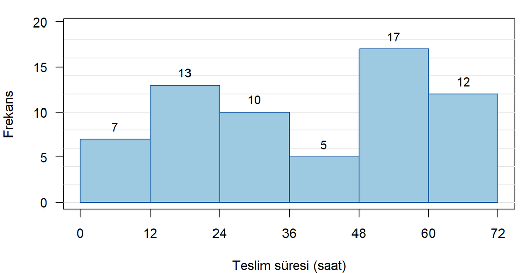

- Toplam gözlem sayısı:
- 36 değerinin altında kalan gözlem sayısı:
- 48 ve üzerindeki gözlemlerin yüzdesi (iki ondalık):

Her dikdörtgenin yüksekliği o sınıfa düşen gözlem sayısıdır.

| Sınıf | [0, 12) | [12, 24) | [24, 36) | [36, 48) | [48, 60) | [60, 72) |
| --- | --- | --- | --- | --- | --- | --- |
| Frekans | 7 | 13 | 10 | 5 | 17 | 12 |

- $n = 7 + 13 + 10 + 5 + 17 + 12 = 64$
- 36 değerinin altı, ilk 3 sınıftır: $7 + 13 + 10 = 30$
- 48 ve üzeri, son 2 sınıftır: $(17 + 12) / 64 \times 100 = 45.31$

En kalabalık sınıf **[48, 60)**. Histogram ham veriyi değil sınıf frekanslarını gösterir: 36 değerinin altında kaç gözlem olduğunu okuyabiliriz, ama bir sınıfın **içinde** gözlemlerin nasıl dağıldığını bilemeyiz.

Aşağıdaki histogram şu veriye aittir: Bir kentteki kafelerin günlük müşteri sayısı. Sınıflar $[a, b)$ biçimindedir.

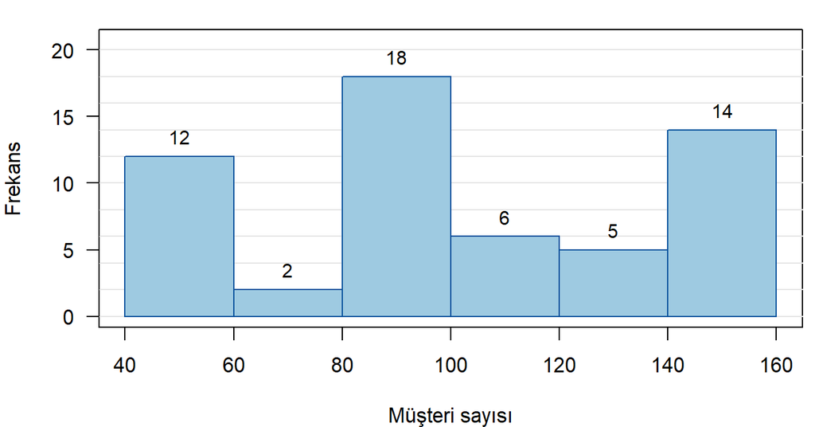

- Toplam gözlem sayısı:
- 80 değerinin altında kalan gözlem sayısı:
- 140 ve üzerindeki gözlemlerin yüzdesi (iki ondalık):

Her dikdörtgenin yüksekliği o sınıfa düşen gözlem sayısıdır.

| Sınıf | [40, 60) | [60, 80) | [80, 100) | [100, 120) | [120, 140) | [140, 160) |
| --- | --- | --- | --- | --- | --- | --- |
| Frekans | 12 | 2 | 18 | 6 | 5 | 14 |

- $n = 12 + 2 + 18 + 6 + 5 + 14 = 57$
- 80 değerinin altı, ilk 2 sınıftır: $12 + 2 = 14$
- 140 ve üzeri, son 1 sınıftır: $(14) / 57 \times 100 = 24.56$

En kalabalık sınıf **[80, 100)**. Histogram ham veriyi değil sınıf frekanslarını gösterir: 80 değerinin altında kaç gözlem olduğunu okuyabiliriz, ama bir sınıfın **içinde** gözlemlerin nasıl dağıldığını bilemeyiz.

Aşağıdaki histogram şu veriye aittir: Bir spor salonu üyelerinin yaşı. Sınıflar $[a, b)$ biçimindedir.

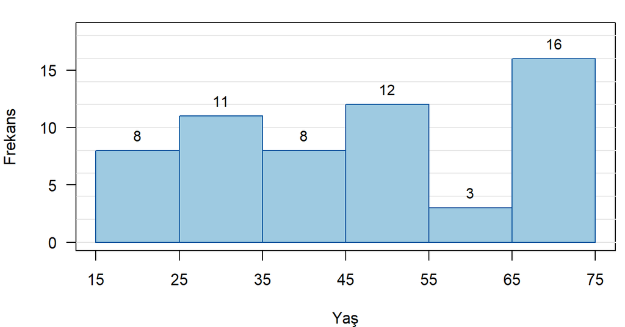

- Toplam gözlem sayısı:
- 25 değerinin altında kalan gözlem sayısı:
- 65 ve üzerindeki gözlemlerin yüzdesi (iki ondalık):

Her dikdörtgenin yüksekliği o sınıfa düşen gözlem sayısıdır.

| Sınıf | [15, 25) | [25, 35) | [35, 45) | [45, 55) | [55, 65) | [65, 75) |
| --- | --- | --- | --- | --- | --- | --- |
| Frekans | 8 | 11 | 8 | 12 | 3 | 16 |

- $n = 8 + 11 + 8 + 12 + 3 + 16 = 58$
- 25 değerinin altı, ilk 1 sınıftır: $8 = 8$
- 65 ve üzeri, son 1 sınıftır: $(16) / 58 \times 100 = 27.59$

En kalabalık sınıf **[65, 75)**. Histogram ham veriyi değil sınıf frekanslarını gösterir: 25 değerinin altında kaç gözlem olduğunu okuyabiliriz, ama bir sınıfın **içinde** gözlemlerin nasıl dağıldığını bilemeyiz.

Aşağıdaki histogram şu veriye aittir: Bir spor salonu üyelerinin yaşı. Sınıflar $[a, b)$ biçimindedir.

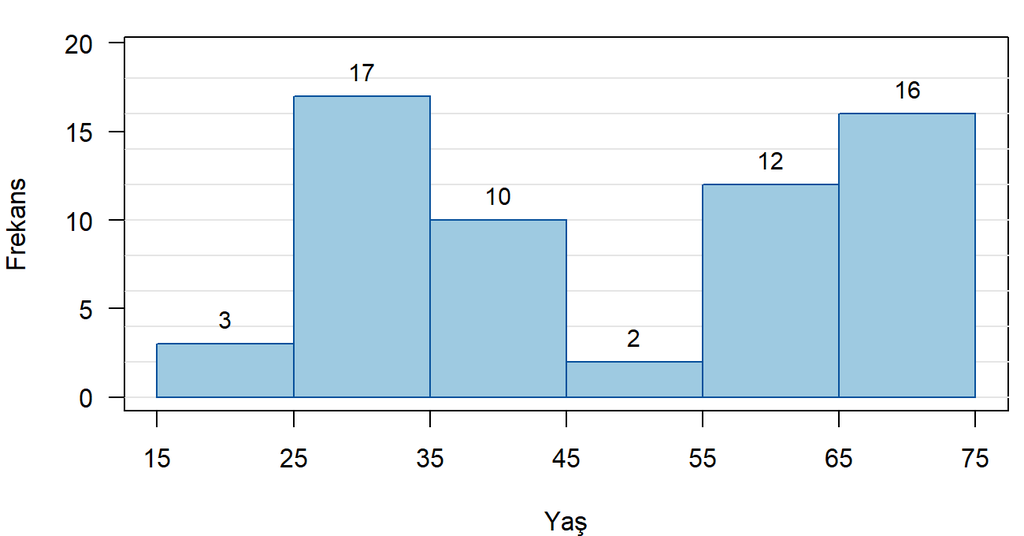

- Toplam gözlem sayısı:
- 25 değerinin altında kalan gözlem sayısı:
- 45 ve üzerindeki gözlemlerin yüzdesi (iki ondalık):

Her dikdörtgenin yüksekliği o sınıfa düşen gözlem sayısıdır.

| Sınıf | [15, 25) | [25, 35) | [35, 45) | [45, 55) | [55, 65) | [65, 75) |
| --- | --- | --- | --- | --- | --- | --- |
| Frekans | 3 | 17 | 10 | 2 | 12 | 16 |

- $n = 3 + 17 + 10 + 2 + 12 + 16 = 60$
- 25 değerinin altı, ilk 1 sınıftır: $3 = 3$
- 45 ve üzeri, son 3 sınıftır: $(2 + 12 + 16) / 60 \times 100 = 50.00$

En kalabalık sınıf **[25, 35)**. Histogram ham veriyi değil sınıf frekanslarını gösterir: 25 değerinin altında kaç gözlem olduğunu okuyabiliriz, ama bir sınıfın **içinde** gözlemlerin nasıl dağıldığını bilemeyiz.

Aşağıdaki grafik şu veriye aittir: Bir doğalgaz dağıtım şirketinin aylık satışı (milyon metreküp), üç yıllık aylık veri.

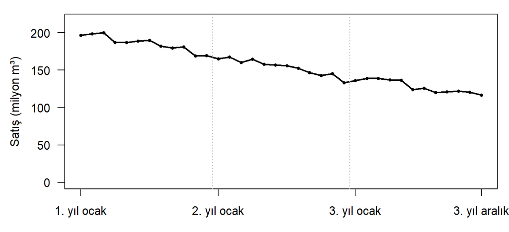

Aşağıdaki ifadelerden **doğru olanların hepsini** işaretleyiniz.

Aylar karıştırılsa bu verinin histogramı değişmezdi ama çizgi grafik değişirdi.Her yıl aynı aylarda tekrarlayan mevsimsel bir dalgalanma var.Seri uzun dönemde düşen bir eğilim gösteriyor.Bu veride gözlemlerin sırası bir bilgi taşımaz.

Zaman serisi grafiğinde önce iki şeye bakılır. Seri uzun dönemde hangi yöne gidiyor (eğilim), yıl içinde aynı aylarda tekrarlayan bir örüntü var mı (mevsimsellik)?

- **Doğru.** Histogram yalnız değerlerin sıklığına bakar, sırayı görmez. Zaman serisinde ise sıra bilginin kendisidir.
- **Yanlış.** Dalgalanmalar düzensiz ve küçük, yıldan yıla aynı aylarda tekrarlanan bir örüntü yok.
- **Doğru.** Üç yılın aylık ortalamaları sırasıyla 185.9, 154.2, 128.2. Seri her yıl daha düşük bir düzeyde, eğilim düşen yönde.
- **Yanlış.** Zaman serisinde gözlemler kronolojik sırayla kaydedilir. Eğilim ve mevsimsellik ancak bu sıra korunursa görülebilir.

Aşağıdaki grafik şu veriye aittir: Bir doğalgaz dağıtım şirketinin aylık satışı (milyon metreküp), üç yıllık aylık veri.

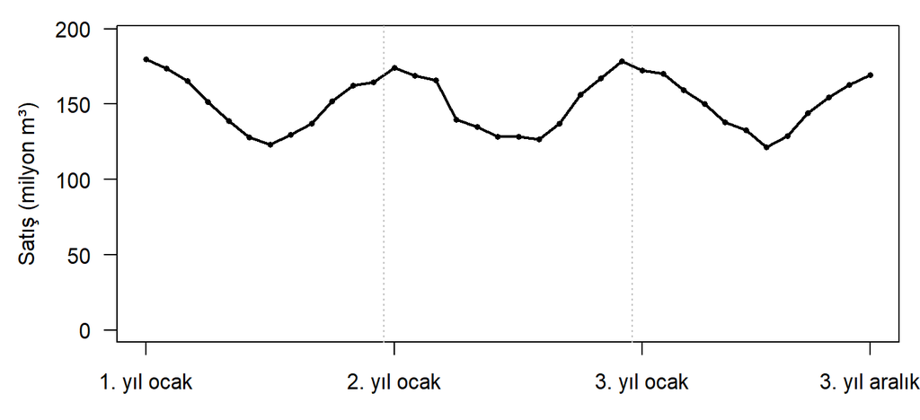

Aşağıdaki ifadelerden **doğru olanların hepsini** işaretleyiniz.

Aylar karıştırılsa bu verinin histogramı değişmezdi ama çizgi grafik değişirdi.Seri uzun dönemde düşen bir eğilim gösteriyor.Bu verinin histogramı serideki eğilimi gösterir.Her yıl aynı aylarda tekrarlayan mevsimsel bir dalgalanma var.

Zaman serisi grafiğinde önce iki şeye bakılır. Seri uzun dönemde hangi yöne gidiyor (eğilim), yıl içinde aynı aylarda tekrarlayan bir örüntü var mı (mevsimsellik)?

- **Doğru.** Histogram yalnız değerlerin sıklığına bakar, sırayı görmez. Zaman serisinde ise sıra bilginin kendisidir.
- **Yanlış.** Üç yılın aylık ortalamaları sırasıyla 150.5, 150.5, 150.4. Ortalamalar birbirine çok yakın, belirgin bir eğilim yok.
- **Yanlış.** Histogram gözlemlerin sırasını görmez. Aylar karıştırılsa histogram değişmez, eğilim ise ancak sıra korunursa görülür.
- **Doğru.** Seri her yıl kış aylarında yükselip altı ay sonra dibe iniyor. Örüntü üç yılda da tekrarlandığı için rastlantı değil.

Aşağıdaki grafik şu veriye aittir: Bir doğalgaz dağıtım şirketinin aylık satışı (milyon metreküp), üç yıllık aylık veri.

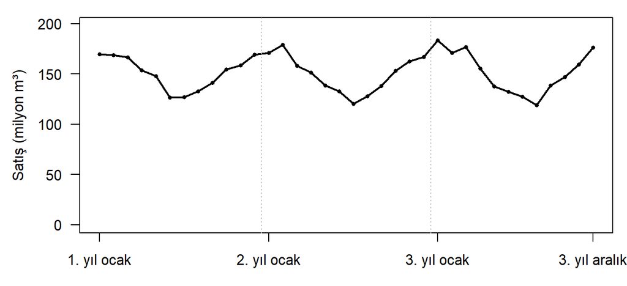

Aşağıdaki ifadelerden **doğru olanların hepsini** işaretleyiniz.

Seri uzun dönemde düşen bir eğilim gösteriyor.Bu veride gözlemlerin sırası bir bilgi taşımaz.Her yıl aynı aylarda tekrarlayan mevsimsel bir dalgalanma var.Aylar karıştırılsa bu verinin histogramı değişmezdi ama çizgi grafik değişirdi.

Zaman serisi grafiğinde önce iki şeye bakılır. Seri uzun dönemde hangi yöne gidiyor (eğilim), yıl içinde aynı aylarda tekrarlayan bir örüntü var mı (mevsimsellik)?

- **Yanlış.** Üç yılın aylık ortalamaları sırasıyla 151.4, 149.9, 152.0. Ortalamalar birbirine çok yakın, belirgin bir eğilim yok.
- **Yanlış.** Zaman serisinde gözlemler kronolojik sırayla kaydedilir. Eğilim ve mevsimsellik ancak bu sıra korunursa görülebilir.
- **Doğru.** Seri her yıl kış aylarında yükselip altı ay sonra dibe iniyor. Örüntü üç yılda da tekrarlandığı için rastlantı değil.
- **Doğru.** Histogram yalnız değerlerin sıklığına bakar, sırayı görmez. Zaman serisinde ise sıra bilginin kendisidir.

Aşağıdaki grafik şu veriye aittir: Bir ilçede aylık su tüketimi (bin metreküp), üç yıllık aylık veri.

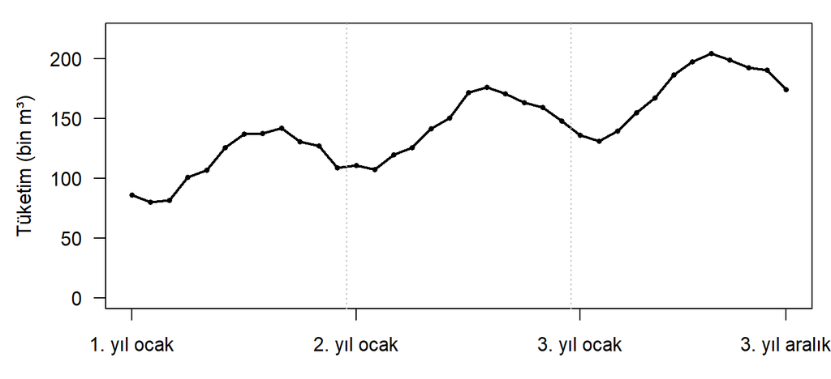

Aşağıdaki ifadelerden **doğru olanların hepsini** işaretleyiniz.

Seri uzun dönemde düşen bir eğilim gösteriyor.Bu veride gözlemlerin sırası bir bilgi taşımaz.Her yıl aynı aylarda tekrarlayan mevsimsel bir dalgalanma var.Aylar karıştırılsa bu verinin histogramı değişmezdi ama çizgi grafik değişirdi.

Zaman serisi grafiğinde önce iki şeye bakılır. Seri uzun dönemde hangi yöne gidiyor (eğilim), yıl içinde aynı aylarda tekrarlayan bir örüntü var mı (mevsimsellik)?

- **Yanlış.** Üç yılın aylık ortalamaları sırasıyla 113.7, 145.3, 172.7. Seri her yıl daha yüksek bir düzeyde, eğilim yükselen yönde.
- **Yanlış.** Zaman serisinde gözlemler kronolojik sırayla kaydedilir. Eğilim ve mevsimsellik ancak bu sıra korunursa görülebilir.
- **Doğru.** Seri her yıl yaz aylarında yükselip altı ay sonra dibe iniyor. Örüntü üç yılda da tekrarlandığı için rastlantı değil.
- **Doğru.** Histogram yalnız değerlerin sıklığına bakar, sırayı görmez. Zaman serisinde ise sıra bilginin kendisidir.

Aşağıdaki grafik şu veriye aittir: Bir ilçede aylık su tüketimi (bin metreküp), üç yıllık aylık veri.

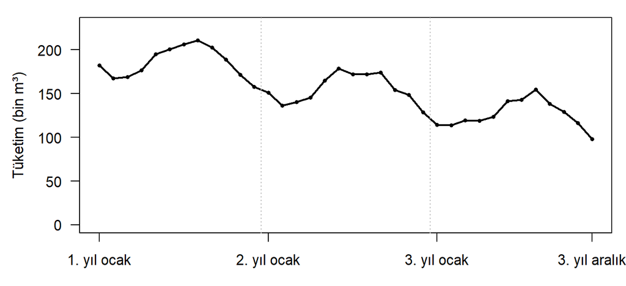

Aşağıdaki ifadelerden **doğru olanların hepsini** işaretleyiniz.

Seri uzun dönemde yükselen bir eğilim gösteriyor.Her yıl aynı aylarda tekrarlayan mevsimsel bir dalgalanma var.Bu verinin histogramı serideki eğilimi gösterir.Bu veride gözlemlerin sırası bir bilgi taşımaz.

Zaman serisi grafiğinde önce iki şeye bakılır. Seri uzun dönemde hangi yöne gidiyor (eğilim), yıl içinde aynı aylarda tekrarlayan bir örüntü var mı (mevsimsellik)?

- **Yanlış.** Üç yılın aylık ortalamaları sırasıyla 185.9, 155.7, 126.0. Seri her yıl daha düşük bir düzeyde, eğilim düşen yönde.
- **Doğru.** Seri her yıl yaz aylarında yükselip altı ay sonra dibe iniyor. Örüntü üç yılda da tekrarlandığı için rastlantı değil.
- **Yanlış.** Histogram gözlemlerin sırasını görmez. Aylar karıştırılsa histogram değişmez, eğilim ise ancak sıra korunursa görülür.
- **Yanlış.** Zaman serisinde gözlemler kronolojik sırayla kaydedilir. Eğilim ve mevsimsellik ancak bu sıra korunursa görülebilir.

Aşağıdaki grafik şu veriye aittir: Bir dondurma üreticisinin aylık satışı (ton), üç yıllık aylık veri.

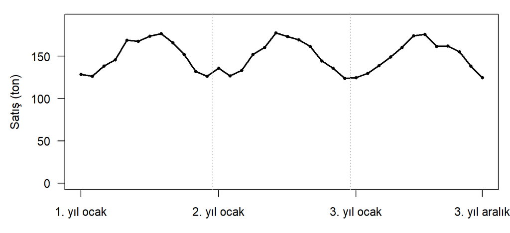

Aşağıdaki ifadelerden **doğru olanların hepsini** işaretleyiniz.

Her yıl aynı aylarda tekrarlayan mevsimsel bir dalgalanma var.Bu verinin histogramı serideki eğilimi gösterir.Aylar karıştırılsa bu verinin histogramı değişmezdi ama çizgi grafik değişirdi.Seri uzun dönemde yükselen bir eğilim gösteriyor.

Zaman serisi grafiğinde önce iki şeye bakılır. Seri uzun dönemde hangi yöne gidiyor (eğilim), yıl içinde aynı aylarda tekrarlayan bir örüntü var mı (mevsimsellik)?

- **Doğru.** Seri her yıl yaz aylarında yükselip altı ay sonra dibe iniyor. Örüntü üç yılda da tekrarlandığı için rastlantı değil.
- **Yanlış.** Histogram gözlemlerin sırasını görmez. Aylar karıştırılsa histogram değişmez, eğilim ise ancak sıra korunursa görülür.
- **Doğru.** Histogram yalnız değerlerin sıklığına bakar, sırayı görmez. Zaman serisinde ise sıra bilginin kendisidir.
- **Yanlış.** Üç yılın aylık ortalamaları sırasıyla 150.3, 149.6, 149.7. Ortalamalar birbirine çok yakın, belirgin bir eğilim yok.

Aşağıdaki grafik şu veriye aittir: Bir dondurma üreticisinin aylık satışı (ton), üç yıllık aylık veri.

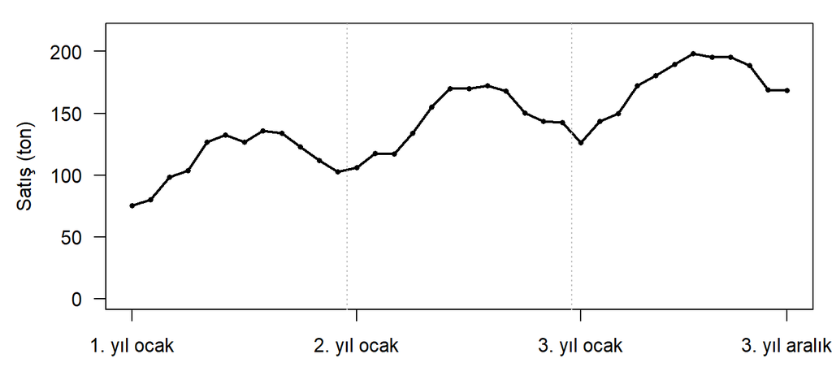

Aşağıdaki ifadelerden **doğru olanların hepsini** işaretleyiniz.

Aylar karıştırılsa bu verinin histogramı değişmezdi ama çizgi grafik değişirdi.Her yıl aynı aylarda tekrarlayan mevsimsel bir dalgalanma var.Seri uzun dönemde yükselen bir eğilim gösteriyor.Bu veride gözlemlerin sırası bir bilgi taşımaz.

Zaman serisi grafiğinde önce iki şeye bakılır. Seri uzun dönemde hangi yöne gidiyor (eğilim), yıl içinde aynı aylarda tekrarlayan bir örüntü var mı (mevsimsellik)?

- **Doğru.** Histogram yalnız değerlerin sıklığına bakar, sırayı görmez. Zaman serisinde ise sıra bilginin kendisidir.
- **Doğru.** Seri her yıl yaz aylarında yükselip altı ay sonra dibe iniyor. Örüntü üç yılda da tekrarlandığı için rastlantı değil.
- **Doğru.** Üç yılın aylık ortalamaları sırasıyla 112.6, 145.5, 173.1. Seri her yıl daha yüksek bir düzeyde, eğilim yükselen yönde.
- **Yanlış.** Zaman serisinde gözlemler kronolojik sırayla kaydedilir. Eğilim ve mevsimsellik ancak bu sıra korunursa görülebilir.

Aşağıdaki grafik şu veriye aittir: Bir doğalgaz dağıtım şirketinin aylık satışı (milyon metreküp), üç yıllık aylık veri.

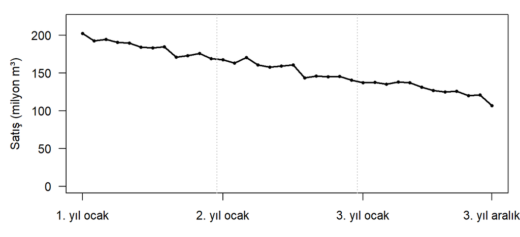

Aşağıdaki ifadelerden **doğru olanların hepsini** işaretleyiniz.

Bu veride gözlemlerin sırası bir bilgi taşımaz.Her yıl aynı aylarda tekrarlayan mevsimsel bir dalgalanma var.Seri uzun dönemde yükselen bir eğilim gösteriyor.Aylar karıştırılsa bu verinin histogramı değişmezdi ama çizgi grafik değişirdi.

Zaman serisi grafiğinde önce iki şeye bakılır. Seri uzun dönemde hangi yöne gidiyor (eğilim), yıl içinde aynı aylarda tekrarlayan bir örüntü var mı (mevsimsellik)?

- **Yanlış.** Zaman serisinde gözlemler kronolojik sırayla kaydedilir. Eğilim ve mevsimsellik ancak bu sıra korunursa görülebilir.
- **Yanlış.** Dalgalanmalar düzensiz ve küçük, yıldan yıla aynı aylarda tekrarlanan bir örüntü yok.
- **Yanlış.** Üç yılın aylık ortalamaları sırasıyla 184.2, 154.9, 128.5. Seri her yıl daha düşük bir düzeyde, eğilim düşen yönde.
- **Doğru.** Histogram yalnız değerlerin sıklığına bakar, sırayı görmez. Zaman serisinde ise sıra bilginin kendisidir.

### Merkezi eğilim

$x = (2,\ 1,\ 1,\ 6,\ 7)$ için aşağıdaki toplamları hesaplayınız ($n = 5$).

- $\sum_{i=1}^{5} x_i =$
- $\sum_{i=1}^{5} x_i^2 =$
- $\left(\sum_{i=1}^{5} x_i\right)^2 =$
- $\sum_{i=1}^{5} (x_i - 4) =$

$$\sum x_i = 2 + 1 + 1 + 6 + 7 = 17$$

$$\sum x_i^2 = 2^2 + 1^2 + 1^2 + 6^2 + 7^2 = 4 + 1 + 1 + 36 + 49 = 91$$

$$\left(\sum x_i\right)^2 = 17^2 = 289$$

$\sum x_i^2$ ile $\left(\sum x_i\right)^2$ **aynı şey değildir**: birinde önce kare alınıp toplanır, ötekinde önce toplanıp kare alınır. Varyans formülünde bu ayrım yeniden karşınıza çıkacak.

Son toplam için kurallar kullanılabilir: $\sum (x_i - c) = \sum x_i - \sum c = \sum x_i - n\,c$.

$$\sum (x_i - 4) = 17 - 5 \times 4 = -3$$

$x = (6,\ 7,\ 9,\ 8,\ 4)$ için aşağıdaki toplamları hesaplayınız ($n = 5$).

- $\sum_{i=1}^{5} x_i =$
- $\sum_{i=1}^{5} x_i^2 =$
- $\left(\sum_{i=1}^{5} x_i\right)^2 =$
- $\sum_{i=1}^{5} (x_i - 2) =$

$$\sum x_i = 6 + 7 + 9 + 8 + 4 = 34$$

$$\sum x_i^2 = 6^2 + 7^2 + 9^2 + 8^2 + 4^2 = 36 + 49 + 81 + 64 + 16 = 246$$

$$\left(\sum x_i\right)^2 = 34^2 = 1156$$

$\sum x_i^2$ ile $\left(\sum x_i\right)^2$ **aynı şey değildir**: birinde önce kare alınıp toplanır, ötekinde önce toplanıp kare alınır. Varyans formülünde bu ayrım yeniden karşınıza çıkacak.

Son toplam için kurallar kullanılabilir: $\sum (x_i - c) = \sum x_i - \sum c = \sum x_i - n\,c$.

$$\sum (x_i - 2) = 34 - 5 \times 2 = 24$$

$x = (7,\ 1,\ 4,\ 1)$ için aşağıdaki toplamları hesaplayınız ($n = 4$).

- $\sum_{i=1}^{4} x_i =$
- $\sum_{i=1}^{4} x_i^2 =$
- $\left(\sum_{i=1}^{4} x_i\right)^2 =$
- $\sum_{i=1}^{4} (x_i - 2) =$

$$\sum x_i = 7 + 1 + 4 + 1 = 13$$

$$\sum x_i^2 = 7^2 + 1^2 + 4^2 + 1^2 = 49 + 1 + 16 + 1 = 67$$

$$\left(\sum x_i\right)^2 = 13^2 = 169$$

$\sum x_i^2$ ile $\left(\sum x_i\right)^2$ **aynı şey değildir**: birinde önce kare alınıp toplanır, ötekinde önce toplanıp kare alınır. Varyans formülünde bu ayrım yeniden karşınıza çıkacak.

Son toplam için kurallar kullanılabilir: $\sum (x_i - c) = \sum x_i - \sum c = \sum x_i - n\,c$.

$$\sum (x_i - 2) = 13 - 4 \times 2 = 5$$

$x = (2,\ 1,\ 8,\ 8,\ 5)$ için aşağıdaki toplamları hesaplayınız ($n = 5$).

- $\sum_{i=1}^{5} x_i =$
- $\sum_{i=1}^{5} x_i^2 =$
- $\left(\sum_{i=1}^{5} x_i\right)^2 =$
- $\sum_{i=1}^{5} (x_i - 3) =$

$$\sum x_i = 2 + 1 + 8 + 8 + 5 = 24$$

$$\sum x_i^2 = 2^2 + 1^2 + 8^2 + 8^2 + 5^2 = 4 + 1 + 64 + 64 + 25 = 158$$

$$\left(\sum x_i\right)^2 = 24^2 = 576$$

$\sum x_i^2$ ile $\left(\sum x_i\right)^2$ **aynı şey değildir**: birinde önce kare alınıp toplanır, ötekinde önce toplanıp kare alınır. Varyans formülünde bu ayrım yeniden karşınıza çıkacak.

Son toplam için kurallar kullanılabilir: $\sum (x_i - c) = \sum x_i - \sum c = \sum x_i - n\,c$.

$$\sum (x_i - 3) = 24 - 5 \times 3 = 9$$

Bir öğrenci evinde yaşayanların haftalık market harcaması (yüz TL):

$$34,\ 25,\ 13,\ 13,\ 39,\ 13,\ 22,\ 5,\ 24$$

- Ortalama $\bar{x}$ (iki ondalık):
- Medyan:
- Mod:

**Ortalama.** $\bar{x} = \dfrac{\sum x_i}{n} = \dfrac{188}{9} = 20.89$

**Medyan.** Önce sıralayın:

$$5,\ 13,\ 13,\ 13,\ 22,\ 24,\ 25,\ 34,\ 39$$

$n = 9$ tek olduğu için medyan $(n+1)/2 = 5$. sıradaki değerdir: **22**.

**Mod.** En sık tekrar eden değer **13** (3 kez).

Bir sınıftaki öğrencilerin bir kısa sınavdan aldığı puan:

$$49,\ 59,\ 22,\ 24,\ 24,\ 43,\ 24,\ 35,\ 46,\ 29,\ 53$$

- Ortalama $\bar{x}$ (iki ondalık):
- Medyan:
- Mod:

**Ortalama.** $\bar{x} = \dfrac{\sum x_i}{n} = \dfrac{408}{11} = 37.09$

**Medyan.** Önce sıralayın:

$$22,\ 24,\ 24,\ 24,\ 29,\ 35,\ 43,\ 46,\ 49,\ 53,\ 59$$

$n = 11$ tek olduğu için medyan $(n+1)/2 = 6$. sıradaki değerdir: **35**.

**Mod.** En sık tekrar eden değer **24** (3 kez).

Bir kafede rassal seçilen müşterilerin masada geçirdiği süre (dakika):

$$29,\ 33,\ 44,\ 30,\ 31,\ 13,\ 58,\ 42,\ 13,\ 41,\ 13$$

- Ortalama $\bar{x}$ (iki ondalık):
- Medyan:
- Mod:

**Ortalama.** $\bar{x} = \dfrac{\sum x_i}{n} = \dfrac{347}{11} = 31.55$

**Medyan.** Önce sıralayın:

$$13,\ 13,\ 13,\ 29,\ 30,\ 31,\ 33,\ 41,\ 42,\ 44,\ 58$$

$n = 11$ tek olduğu için medyan $(n+1)/2 = 6$. sıradaki değerdir: **31**.

**Mod.** En sık tekrar eden değer **13** (3 kez).

Bir kargo şubesinde günlük teslim edilen paket sayısı:

$$86,\ 56,\ 52,\ 56,\ 48,\ 56,\ 67,\ 42,\ 49,\ 31,\ 39$$

- Ortalama $\bar{x}$ (iki ondalık):
- Medyan:
- Mod:

**Ortalama.** $\bar{x} = \dfrac{\sum x_i}{n} = \dfrac{582}{11} = 52.91$

**Medyan.** Önce sıralayın:

$$31,\ 39,\ 42,\ 48,\ 49,\ 52,\ 56,\ 56,\ 56,\ 67,\ 86$$

$n = 11$ tek olduğu için medyan $(n+1)/2 = 6$. sıradaki değerdir: **52**.

**Mod.** En sık tekrar eden değer **56** (3 kez).

Bir lokanta bir hafta içinde dört kez domates almıştır. Kilogram fiyatları (TL) ve alınan miktarlar (kg) aşağıdadır.

| Alım | 1. alım | 2. alım | 3. alım | 4. alım |
| --- | --- | --- | --- | --- |
| Miktar (kg) | 200 | 100 | 50 | 100 |
| Fiyat (TL/kg) | 42 | 44 | 28 | 38 |

- Aritmetik ortalama (iki ondalık):
- Miktar ağırlıklı ortalama kilogram fiyatı (iki ondalık):

**Aritmetik ortalama** her gözleme aynı ağırlığı verir:

$$\frac{42 + 44 + 28 + 38}{4} = 38.00$$

**Ağırlıklı ortalama** her gözlemi ağırlığıyla çarpar ve ağırlıkların toplamına böler:

$$\bar{x}_w = \frac{\sum w_i x_i}{\sum w_i} = \frac{200 \cdot 42 + 100 \cdot 44 + 50 \cdot 28 + 100 \cdot 38}{200 + 100 + 50 + 100} = \frac{18000}{450} = 40.00$$

Ağırlıklı ortalama daha yüksek: ağırlığı büyük olan gözlemlerin değerleri görece yüksek. Bütün ağırlıklar eşit olsaydı iki ortalama aynı olurdu. Lokantanın bir kilograma ödediği gerçek ortalama fiyat ağırlıklı ortalamadır: toplam ödenen para / toplam kilogram.

Bir lokanta bir hafta içinde dört kez domates almıştır. Kilogram fiyatları (TL) ve alınan miktarlar (kg) aşağıdadır.

| Alım | 1. alım | 2. alım | 3. alım | 4. alım |
| --- | --- | --- | --- | --- |
| Miktar (kg) | 50 | 50 | 150 | 150 |
| Fiyat (TL/kg) | 42 | 46 | 32 | 38 |

- Aritmetik ortalama (iki ondalık):
- Miktar ağırlıklı ortalama kilogram fiyatı (iki ondalık):

**Aritmetik ortalama** her gözleme aynı ağırlığı verir:

$$\frac{42 + 46 + 32 + 38}{4} = 39.50$$

**Ağırlıklı ortalama** her gözlemi ağırlığıyla çarpar ve ağırlıkların toplamına böler:

$$\bar{x}_w = \frac{\sum w_i x_i}{\sum w_i} = \frac{50 \cdot 42 + 50 \cdot 46 + 150 \cdot 32 + 150 \cdot 38}{50 + 50 + 150 + 150} = \frac{14900}{400} = 37.25$$

Ağırlıklı ortalama daha düşük: ağırlığı büyük olan gözlemlerin değerleri görece düşük. Bütün ağırlıklar eşit olsaydı iki ortalama aynı olurdu. Lokantanın bir kilograma ödediği gerçek ortalama fiyat ağırlıklı ortalamadır: toplam ödenen para / toplam kilogram.

Bir lokanta bir hafta içinde dört kez domates almıştır. Kilogram fiyatları (TL) ve alınan miktarlar (kg) aşağıdadır.

| Alım | 1. alım | 2. alım | 3. alım | 4. alım |
| --- | --- | --- | --- | --- |
| Miktar (kg) | 150 | 300 | 300 | 50 |
| Fiyat (TL/kg) | 38 | 30 | 28 | 34 |

- Aritmetik ortalama (iki ondalık):
- Miktar ağırlıklı ortalama kilogram fiyatı (iki ondalık):

**Aritmetik ortalama** her gözleme aynı ağırlığı verir:

$$\frac{38 + 30 + 28 + 34}{4} = 32.50$$

**Ağırlıklı ortalama** her gözlemi ağırlığıyla çarpar ve ağırlıkların toplamına böler:

$$\bar{x}_w = \frac{\sum w_i x_i}{\sum w_i} = \frac{150 \cdot 38 + 300 \cdot 30 + 300 \cdot 28 + 50 \cdot 34}{150 + 300 + 300 + 50} = \frac{24800}{800} = 31.00$$

Ağırlıklı ortalama daha düşük: ağırlığı büyük olan gözlemlerin değerleri görece düşük. Bütün ağırlıklar eşit olsaydı iki ortalama aynı olurdu. Lokantanın bir kilograma ödediği gerçek ortalama fiyat ağırlıklı ortalamadır: toplam ödenen para / toplam kilogram.

Bir lokanta bir hafta içinde dört kez domates almıştır. Kilogram fiyatları (TL) ve alınan miktarlar (kg) aşağıdadır.

| Alım | 1. alım | 2. alım | 3. alım | 4. alım |
| --- | --- | --- | --- | --- |
| Miktar (kg) | 300 | 150 | 150 | 150 |
| Fiyat (TL/kg) | 46 | 36 | 28 | 38 |

- Aritmetik ortalama (iki ondalık):
- Miktar ağırlıklı ortalama kilogram fiyatı (iki ondalık):

**Aritmetik ortalama** her gözleme aynı ağırlığı verir:

$$\frac{46 + 36 + 28 + 38}{4} = 37.00$$

**Ağırlıklı ortalama** her gözlemi ağırlığıyla çarpar ve ağırlıkların toplamına böler:

$$\bar{x}_w = \frac{\sum w_i x_i}{\sum w_i} = \frac{300 \cdot 46 + 150 \cdot 36 + 150 \cdot 28 + 150 \cdot 38}{300 + 150 + 150 + 150} = \frac{29100}{750} = 38.80$$

Ağırlıklı ortalama daha yüksek: ağırlığı büyük olan gözlemlerin değerleri görece yüksek. Bütün ağırlıklar eşit olsaydı iki ortalama aynı olurdu. Lokantanın bir kilograma ödediği gerçek ortalama fiyat ağırlıklı ortalamadır: toplam ödenen para / toplam kilogram.

Bir ilçedeki ortalama konut fiyatı 5 yıl boyunca sırasıyla %20, %5, −%15, %5 ve −%20 oranında değişmiştir. Başlangıçta ortalama konut fiyatı 2500 bin TL idi.

Yüzdeleri iki ondalıkla ve % işareti olmadan yazınız: %4.38 için 4.38. Değer eksiyse başına - koyunuz.

- Yıllık büyüme oranlarının aritmetik ortalaması (%):
- Yıllık büyüme oranlarının geometrik ortalaması (%):
- Başlangıç değeri her yıl **aritmetik ortalama** oranda büyüseydi 5 yıl sonunda kaç bin TL olurdu?

**Aritmetik ortalama**

$$\bar{g}_a = \frac{0.2000 + 0.0500 - 0.1500 + 0.0500 - 0.2000}{5} = -0.0100, \quad \text{yani } \%-1.00$$

**Geometrik ortalama** oranların kendisini değil 1 eklenmiş hâllerini çarpar:

$$\bar{g} = \left(1.2000 \times 1.0500 \times 0.8500 \times 1.0500 \times 0.8000\right)^{1/5} - 1 = 0.8996^{1/5} - 1 = -0.0209, \quad \text{yani } \%-2.09$$

Çarpım, dönem sonu değerinin başlangıç değerine oranıdır: $2249.1 / 2500 = 0.8996$. Bu yüzden dönem sonu değeri $V_n$, başlangıç değeri $V_0$ ise geometrik ortalama doğrudan $\left(V_n / V_0\right)^{1/n} - 1$ olarak da bulunabilir.

**Aritmetik ortalamayla büyütmek**

$$2500 \times (1 - 0.0100)^{5} = 2377.48$$

Gerçekleşen değer ise 2249.1 bin TL. Geometrik ortalamayla büyütmek tam olarak bu değeri verir: $2500 \times (1 - 0.0209)^{5} = 2249.1$. Aritmetik ortalama, oranlar dalgalandığında büyümeyi olduğundan yüksek gösterir.

Bir ilçedeki ortalama konut fiyatı başlangıçta 2500 bin TL idi. Sonraki 4 yılın sonundaki değerler (bin TL) aşağıdadır.

| Yıl | 0 | 1 | 2 | 3 | 4 |
| --- | --- | --- | --- | --- | --- |
| Değer | 2500 | 2125.0 | 2762.5 | 3038.8 | 3646.5 |

Yüzdeleri iki ondalıkla ve % işareti olmadan yazınız: %4.38 için 4.38. Değer eksiyse başına - koyunuz.

- Yıllık büyüme oranlarının aritmetik ortalaması (%):
- Yıllık büyüme oranlarının geometrik ortalaması (%):
- Başlangıç değeri her yıl **aritmetik ortalama** oranda büyüseydi 4 yıl sonunda kaç bin TL olurdu?

Önce her yılın büyüme oranı bulunur: $2500 \rightarrow 2125.0$: −%15.00, $2125.0 \rightarrow 2762.5$: %30.00, $2762.5 \rightarrow 3038.8$: %10.00, $3038.8 \rightarrow 3646.5$: %20.00.

**Aritmetik ortalama**

$$\bar{g}_a = \frac{-0.1500 + 0.3000 + 0.1000 + 0.2000}{4} = 0.1125, \quad \text{yani } \%11.25$$

**Geometrik ortalama** oranların kendisini değil 1 eklenmiş hâllerini çarpar:

$$\bar{g} = \left(0.8500 \times 1.3000 \times 1.1000 \times 1.2000\right)^{1/4} - 1 = 1.4586^{1/4} - 1 = 0.0990, \quad \text{yani } \%9.90$$

Çarpım, dönem sonu değerinin başlangıç değerine oranıdır: $3646.5 / 2500 = 1.4586$. Bu yüzden dönem sonu değeri $V_n$, başlangıç değeri $V_0$ ise geometrik ortalama doğrudan $\left(V_n / V_0\right)^{1/n} - 1$ olarak da bulunabilir.

**Aritmetik ortalamayla büyütmek**

$$2500 \times (1 + 0.1125)^{4} = 3829.48$$

Gerçekleşen değer ise 3646.5 bin TL. Geometrik ortalamayla büyütmek tam olarak bu değeri verir: $2500 \times (1 + 0.0990)^{4} = 3646.5$. Aritmetik ortalama, oranlar dalgalandığında büyümeyi olduğundan yüksek gösterir.

Bir şirketin yıllık cirosu 4 yıl boyunca sırasıyla %10, %5, −%10 ve −%20 oranında değişmiştir. Başlangıçta ciro 400 milyon TL idi.

Yüzdeleri iki ondalıkla ve % işareti olmadan yazınız: %4.38 için 4.38. Değer eksiyse başına - koyunuz.

- Yıllık büyüme oranlarının aritmetik ortalaması (%):
- Yıllık büyüme oranlarının geometrik ortalaması (%):
- Başlangıç değeri her yıl **aritmetik ortalama** oranda büyüseydi 4 yıl sonunda kaç milyon TL olurdu?

**Aritmetik ortalama**

$$\bar{g}_a = \frac{0.1000 + 0.0500 - 0.1000 - 0.2000}{4} = -0.0375, \quad \text{yani } \%-3.75$$

**Geometrik ortalama** oranların kendisini değil 1 eklenmiş hâllerini çarpar:

$$\bar{g} = \left(1.1000 \times 1.0500 \times 0.9000 \times 0.8000\right)^{1/4} - 1 = 0.8316^{1/4} - 1 = -0.0451, \quad \text{yani } \%-4.51$$

Çarpım, dönem sonu değerinin başlangıç değerine oranıdır: $332.6 / 400 = 0.8316$. Bu yüzden dönem sonu değeri $V_n$, başlangıç değeri $V_0$ ise geometrik ortalama doğrudan $\left(V_n / V_0\right)^{1/n} - 1$ olarak da bulunabilir.

**Aritmetik ortalamayla büyütmek**

$$400 \times (1 - 0.0375)^{4} = 343.29$$

Gerçekleşen değer ise 332.6 milyon TL. Geometrik ortalamayla büyütmek tam olarak bu değeri verir: $400 \times (1 - 0.0451)^{4} = 332.6$. Aritmetik ortalama, oranlar dalgalandığında büyümeyi olduğundan yüksek gösterir.

Bir yatırım fonuna yatırılan paranın değeri başlangıçta 1000 TL idi. Sonraki 5 yılın sonundaki değerler (TL) aşağıdadır.

| Yıl | 0 | 1 | 2 | 3 | 4 | 5 |
| --- | --- | --- | --- | --- | --- | --- |
| Değer | 1000 | 900.0 | 855.0 | 726.8 | 944.8 | 1039.3 |

Yüzdeleri iki ondalıkla ve % işareti olmadan yazınız: %4.38 için 4.38. Değer eksiyse başına - koyunuz.

- Yıllık büyüme oranlarının aritmetik ortalaması (%):
- Yıllık büyüme oranlarının geometrik ortalaması (%):
- Başlangıç değeri her yıl **aritmetik ortalama** oranda büyüseydi 5 yıl sonunda kaç TL olurdu?

Önce her yılın büyüme oranı bulunur: $1000 \rightarrow 900.0$: −%10.00, $900.0 \rightarrow 855.0$: −%5.00, $855.0 \rightarrow 726.8$: −%14.99, $726.8 \rightarrow 944.8$: %29.99, $944.8 \rightarrow 1039.3$: %10.00.

**Aritmetik ortalama**

$$\bar{g}_a = \frac{-0.1000 - 0.0500 - 0.1499 + 0.2999 + 0.1000}{5} = 0.0200, \quad \text{yani } \%2.00$$

**Geometrik ortalama** oranların kendisini değil 1 eklenmiş hâllerini çarpar:

$$\bar{g} = \left(0.9000 \times 0.9500 \times 0.8501 \times 1.2999 \times 1.1000\right)^{1/5} - 1 = 1.0393^{1/5} - 1 = 0.0077, \quad \text{yani } \%0.77$$

Çarpım, dönem sonu değerinin başlangıç değerine oranıdır: $1039.3 / 1000 = 1.0393$. Bu yüzden dönem sonu değeri $V_n$, başlangıç değeri $V_0$ ise geometrik ortalama doğrudan $\left(V_n / V_0\right)^{1/n} - 1$ olarak da bulunabilir.

**Aritmetik ortalamayla büyütmek**

$$1000 \times (1 + 0.0200)^{5} = 1104.11$$

Gerçekleşen değer ise 1039.3 TL. Geometrik ortalamayla büyütmek tam olarak bu değeri verir: $1000 \times (1 + 0.0077)^{5} = 1039.3$. Aritmetik ortalama, oranlar dalgalandığında büyümeyi olduğundan yüksek gösterir.

Bir sokaktaki 8 hanenin aylık geliri (bin TL) aşağıdadır. Sokağa aylık geliri 600 bin TL olan bir hane taşınıyor.

$$19,\ 31,\ 28,\ 32,\ 14,\ 37,\ 36,\ 33$$

Eklemeden önce: ortalama = 28.75 bin TL, medyan = 31.5 bin TL.

- Ekleme sonrası ortalama (iki ondalık):
- Ekleme sonrası medyan:

**Yeni ortalama.** Toplam: 230 → 830; gözlem sayısı: 8 → 9.

$$\bar{x} = \frac{830}{9} = 92.22$$

**Yeni medyan.** Sıralı veri ($n = 9$):

$$14,\ 19,\ 28,\ 31,\ 32,\ 33,\ 36,\ 37,\ 600$$

Medyan 5. sıradaki değer: **32**.

Ortalama 63.47 birim değişti (28.75 → 92.22), medyan ise 0.50 birim (31.5 → 32). Medyan sıralamaya dayandığı için uç değerin **büyüklüğüne** değil, yalnızca sıralamada **hangi tarafta** olduğuna bakar. Bu sokağın tipik hanesini ortalama değil medyan anlatır.

Bir sokaktaki 8 hanenin aylık geliri (bin TL) aşağıdadır. Sokağa aylık geliri 2400 bin TL olan bir hane taşınıyor.

$$23,\ 14,\ 40,\ 19,\ 29,\ 34,\ 20,\ 22$$

Eklemeden önce: ortalama = 25.12 bin TL, medyan = 22.5 bin TL.

- Ekleme sonrası ortalama (iki ondalık):
- Ekleme sonrası medyan:

**Yeni ortalama.** Toplam: 201 → 2601; gözlem sayısı: 8 → 9.

$$\bar{x} = \frac{2601}{9} = 289.00$$

**Yeni medyan.** Sıralı veri ($n = 9$):

$$14,\ 19,\ 20,\ 22,\ 23,\ 29,\ 34,\ 40,\ 2400$$

Medyan 5. sıradaki değer: **23**.

Ortalama 263.88 birim değişti (25.12 → 289.00), medyan ise 0.50 birim (22.5 → 23). Medyan sıralamaya dayandığı için uç değerin **büyüklüğüne** değil, yalnızca sıralamada **hangi tarafta** olduğuna bakar. Bu sokağın tipik hanesini ortalama değil medyan anlatır.

Bir sokaktaki 9 hanenin aylık geliri (bin TL) aşağıdadır. Sokağa aylık geliri 600 bin TL olan bir hane taşınıyor.

$$30,\ 40,\ 19,\ 17,\ 14,\ 32,\ 15,\ 26,\ 18$$

Eklemeden önce: ortalama = 23.44 bin TL, medyan = 19 bin TL.

- Ekleme sonrası ortalama (iki ondalık):
- Ekleme sonrası medyan:

**Yeni ortalama.** Toplam: 211 → 811; gözlem sayısı: 9 → 10.

$$\bar{x} = \frac{811}{10} = 81.10$$

**Yeni medyan.** Sıralı veri ($n = 10$):

$$14,\ 15,\ 17,\ 18,\ 19,\ 26,\ 30,\ 32,\ 40,\ 600$$

Medyan 5. ve 6. değerlerin ortalaması: $(19 + 26)/2 = 22.5$.

Ortalama 57.66 birim değişti (23.44 → 81.10), medyan ise 3.50 birim (19 → 22.5). Medyan sıralamaya dayandığı için uç değerin **büyüklüğüne** değil, yalnızca sıralamada **hangi tarafta** olduğuna bakar. Bu sokağın tipik hanesini ortalama değil medyan anlatır.

Bir kısa sınava giren 10 öğrencinin notları aşağıdadır. Sınava girmeyen bir öğrenci için sisteme 0 yazılmıştır.

$$50,\ 75,\ 73,\ 74,\ 85,\ 79,\ 69,\ 68,\ 89,\ 62$$

Eklemeden önce: ortalama = 72.40, medyan = 73.5.

- Ekleme sonrası ortalama (iki ondalık):
- Ekleme sonrası medyan:

**Yeni ortalama.** Toplam: 724 → 724; gözlem sayısı: 10 → 11.

$$\bar{x} = \frac{724}{11} = 65.82$$

**Yeni medyan.** Sıralı veri ($n = 11$):

$$0,\ 50,\ 62,\ 68,\ 69,\ 73,\ 74,\ 75,\ 79,\ 85,\ 89$$

Medyan 6. sıradaki değer: **73**.

Ortalama 6.58 birim değişti (72.40 → 65.82), medyan ise 0.50 birim (73.5 → 73). Medyan sıralamaya dayandığı için uç değerin **büyüklüğüne** değil, yalnızca sıralamada **hangi tarafta** olduğuna bakar. Sınava girmeyene 0 yazmak ortalamayı ciddi biçimde bozar; bu öğrencinin veriden çıkarılması daha doğru olur.

### Kantiller

Bir mağazada müşterilerin bekleme süreleri (dakika) için birikimli yüzde eğrisi (ogive) aşağıdadır ($n = 50$). Noktalardaki sayılar birikimli yüzdelerdir; her nokta sınıfın **üst sınırına** işaretlenmiştir.

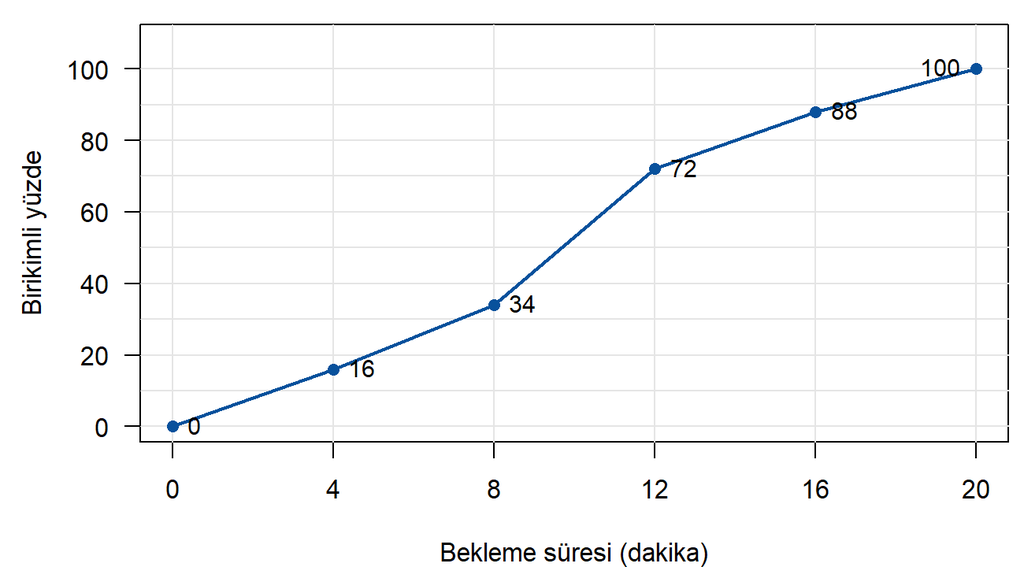

- Müşterilerin yüzde kaçı 8 değerinin altındadır?
- Müşterilerin yüzde kaçı 4 ile 12 arasındadır?

**Altında kalan oran.** 8 noktasındaki yükseklik doğrudan okunur: **%34**.

**İki değer arası.** Üst sınırdaki birikimli yüzdeden alt sınırdakini çıkarın: $72 - 16 = 56$.

Ogive her noktada “bu değerin altında gözlemlerin yüzde kaçı var?” sorusunu yanıtlar. Eğri hiç inmez, çünkü her sınıf birikimli yüzdeye yalnızca ekleme yapar. Eğrinin dik yükseldiği aralıklar gözlemlerin yoğunlaştığı sınıflardır.

Bir mağazada müşterilerin bekleme süreleri (dakika) için birikimli yüzde eğrisi (ogive) aşağıdadır ($n = 50$). Noktalardaki sayılar birikimli yüzdelerdir; her nokta sınıfın **üst sınırına** işaretlenmiştir.

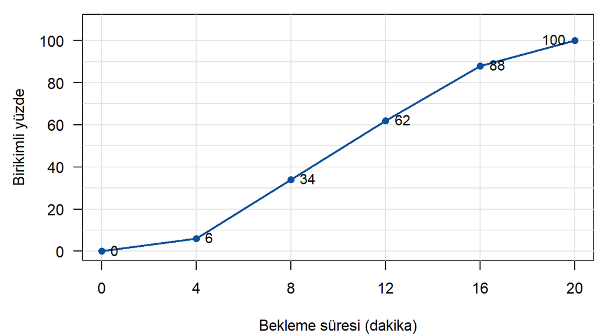

- Müşterilerin yüzde kaçı 12 değerinin altındadır?
- Müşterilerin yüzde kaçı 4 ile 12 arasındadır?

**Altında kalan oran.** 12 noktasındaki yükseklik doğrudan okunur: **%62**.

**İki değer arası.** Üst sınırdaki birikimli yüzdeden alt sınırdakini çıkarın: $62 - 6 = 56$.

Ogive her noktada “bu değerin altında gözlemlerin yüzde kaçı var?” sorusunu yanıtlar. Eğri hiç inmez, çünkü her sınıf birikimli yüzdeye yalnızca ekleme yapar. Eğrinin dik yükseldiği aralıklar gözlemlerin yoğunlaştığı sınıflardır.

Bir kurstaki katılımcıların yaşları için birikimli yüzde eğrisi (ogive) aşağıdadır ($n = 50$). Noktalardaki sayılar birikimli yüzdelerdir; her nokta sınıfın **üst sınırına** işaretlenmiştir.

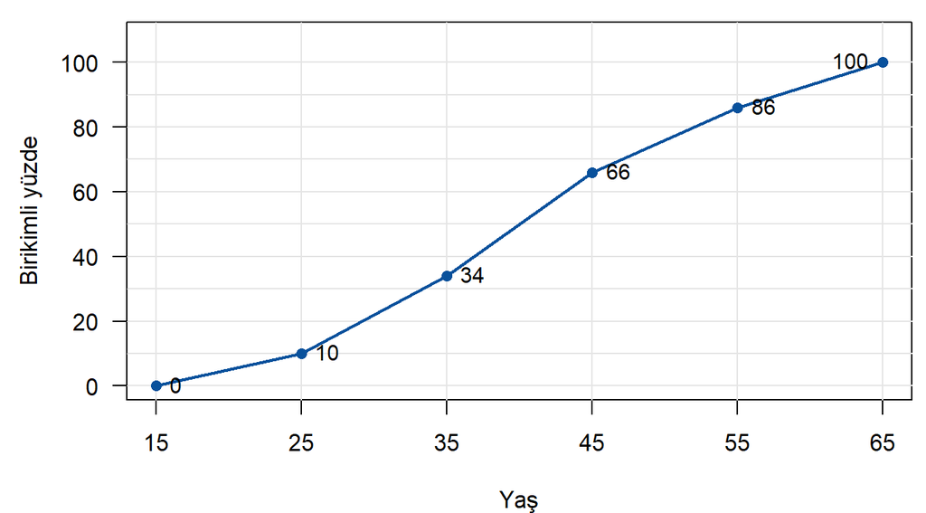

- Katılımcıların yüzde kaçı 35 değerinin altındadır?
- Katılımcıların yüzde kaçı 35 ile 55 arasındadır?

**Altında kalan oran.** 35 noktasındaki yükseklik doğrudan okunur: **%34**.

**İki değer arası.** Üst sınırdaki birikimli yüzdeden alt sınırdakini çıkarın: $86 - 34 = 52$.

Ogive her noktada “bu değerin altında gözlemlerin yüzde kaçı var?” sorusunu yanıtlar. Eğri hiç inmez, çünkü her sınıf birikimli yüzdeye yalnızca ekleme yapar. Eğrinin dik yükseldiği aralıklar gözlemlerin yoğunlaştığı sınıflardır.

Bir mağazada müşterilerin bekleme süreleri (dakika) için birikimli yüzde eğrisi (ogive) aşağıdadır ($n = 50$). Noktalardaki sayılar birikimli yüzdelerdir; her nokta sınıfın **üst sınırına** işaretlenmiştir.

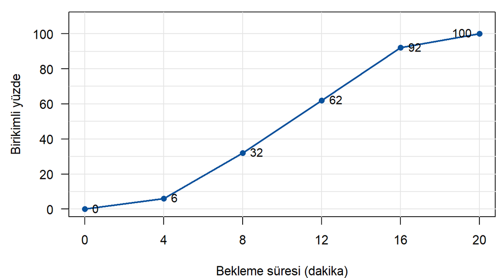

- Müşterilerin yüzde kaçı 12 değerinin altındadır?
- Müşterilerin yüzde kaçı 8 ile 16 arasındadır?

**Altında kalan oran.** 12 noktasındaki yükseklik doğrudan okunur: **%62**.

**İki değer arası.** Üst sınırdaki birikimli yüzdeden alt sınırdakini çıkarın: $92 - 32 = 60$.

Ogive her noktada “bu değerin altında gözlemlerin yüzde kaçı var?” sorusunu yanıtlar. Eğri hiç inmez, çünkü her sınıf birikimli yüzdeye yalnızca ekleme yapar. Eğrinin dik yükseldiği aralıklar gözlemlerin yoğunlaştığı sınıflardır.

Bir bölümdeki 11 öğrencinin bir sınavdan aldığı notlar:

$$54,\ 94,\ 68,\ 21,\ 70,\ 20,\ 82,\ 29,\ 86,\ 95,\ 67$$

Derste gördüğümüz yöntemle ($p$ oranına karşılık gelen değer $(n+1)p$’inci sıradaki değer, gerekirse iki komşu değer arasında doğrusal interpolasyon) hesaplayınız. İki ondalık basamak kullanınız.

- Birinci kartil $Q_1$:
- Üçüncü kartil $Q_3$:
- 90’ıncı yüzdelik:

Sıralı veri:

| Sıra | 1 | 2 | 3 | 4 | 5 | 6 | 7 | 8 | 9 | 10 | 11 |
| --- | --- | --- | --- | --- | --- | --- | --- | --- | --- | --- | --- |
| Not | 20 | 21 | 29 | 54 | 67 | 68 | 70 | 82 | 86 | 94 | 95 |

**$Q_1$ ($p = 0.25$).** $(n+1)p = 12 \times 0.25 = 3$ tam sayı: Q_1 doğrudan $x_{(3)} = 29$.

**$Q_3$ ($p = 0.75$).** $(n+1)p = 12 \times 0.75 = 9$ tam sayı: Q_3 doğrudan $x_{(9)} = 86$.

**90’ıncı yüzdelik ($p = 0.9$).** $(n+1)p = 12 \times 0.9 = 10.8$: 10. ile 11. sıra arasında. $P_{90} = x_{(10)} + 0.8\,(x_{(11)} - x_{(10)}) = 94 + 0.8 \times (95 - 94) = 94.8$

Tam sayı kısmı hangi iki gözlemin arasında olduğumuzu, ondalık kısmı aradaki mesafenin ne kadarını ekleyeceğimizi söyler. Yorum: öğrencilerin yaklaşık yüzde 90 kadarı 94.8 puanın altında not almıştır.

R’da aynı yöntem `quantile(x, c(0.25, 0.75, 0.9), type = 6)` ile uygulanır. R’ın varsayılan yöntemi (`type = 7`) küçük veride biraz farklı sonuç verir.

Bir bölümdeki 13 öğrencinin bir sınavdan aldığı notlar:

$$83,\ 82,\ 30,\ 22,\ 29,\ 44,\ 80,\ 53,\ 85,\ 68,\ 63,\ 31,\ 81$$

Derste gördüğümüz yöntemle ($p$ oranına karşılık gelen değer $(n+1)p$’inci sıradaki değer, gerekirse iki komşu değer arasında doğrusal interpolasyon) hesaplayınız. İki ondalık basamak kullanınız.

- Birinci kartil $Q_1$:
- Üçüncü kartil $Q_3$:
- 60’ıncı yüzdelik:

Sıralı veri:

| Sıra | 1 | 2 | 3 | 4 | 5 | 6 | 7 | 8 | 9 | 10 | 11 | 12 | 13 |
| --- | --- | --- | --- | --- | --- | --- | --- | --- | --- | --- | --- | --- | --- |
| Not | 22 | 29 | 30 | 31 | 44 | 53 | 63 | 68 | 80 | 81 | 82 | 83 | 85 |

**$Q_1$ ($p = 0.25$).** $(n+1)p = 14 \times 0.25 = 3.5$: 3. ile 4. sıra arasında. $Q_1 = x_{(3)} + 0.5\,(x_{(4)} - x_{(3)}) = 30 + 0.5 \times (31 - 30) = 30.5$

**$Q_3$ ($p = 0.75$).** $(n+1)p = 14 \times 0.75 = 10.5$: 10. ile 11. sıra arasında. $Q_3 = x_{(10)} + 0.5\,(x_{(11)} - x_{(10)}) = 81 + 0.5 \times (82 - 81) = 81.5$

**60’ıncı yüzdelik ($p = 0.6$).** $(n+1)p = 14 \times 0.6 = 8.4$: 8. ile 9. sıra arasında. $P_{60} = x_{(8)} + 0.4\,(x_{(9)} - x_{(8)}) = 68 + 0.4 \times (80 - 68) = 72.8$

Tam sayı kısmı hangi iki gözlemin arasında olduğumuzu, ondalık kısmı aradaki mesafenin ne kadarını ekleyeceğimizi söyler. Yorum: öğrencilerin yaklaşık yüzde 60 kadarı 72.8 puanın altında not almıştır.

R’da aynı yöntem `quantile(x, c(0.25, 0.75, 0.6), type = 6)` ile uygulanır. R’ın varsayılan yöntemi (`type = 7`) küçük veride biraz farklı sonuç verir.

Bir bölümdeki 15 öğrencinin bir sınavdan aldığı notlar:

$$30,\ 60,\ 83,\ 42,\ 23,\ 49,\ 78,\ 57,\ 20,\ 47,\ 51,\ 50,\ 22,\ 52,\ 95$$

Derste gördüğümüz yöntemle ($p$ oranına karşılık gelen değer $(n+1)p$’inci sıradaki değer, gerekirse iki komşu değer arasında doğrusal interpolasyon) hesaplayınız. İki ondalık basamak kullanınız.

- Birinci kartil $Q_1$:
- Üçüncü kartil $Q_3$:
- 60’ıncı yüzdelik:

Sıralı veri:

| Sıra | 1 | 2 | 3 | 4 | 5 | 6 | 7 | 8 | 9 | 10 | 11 | 12 | 13 | 14 | 15 |
| --- | --- | --- | --- | --- | --- | --- | --- | --- | --- | --- | --- | --- | --- | --- | --- |
| Not | 20 | 22 | 23 | 30 | 42 | 47 | 49 | 50 | 51 | 52 | 57 | 60 | 78 | 83 | 95 |

**$Q_1$ ($p = 0.25$).** $(n+1)p = 16 \times 0.25 = 4$ tam sayı: Q_1 doğrudan $x_{(4)} = 30$.

**$Q_3$ ($p = 0.75$).** $(n+1)p = 16 \times 0.75 = 12$ tam sayı: Q_3 doğrudan $x_{(12)} = 60$.

**60’ıncı yüzdelik ($p = 0.6$).** $(n+1)p = 16 \times 0.6 = 9.6$: 9. ile 10. sıra arasında. $P_{60} = x_{(9)} + 0.6\,(x_{(10)} - x_{(9)}) = 51 + 0.6 \times (52 - 51) = 51.6$

Tam sayı kısmı hangi iki gözlemin arasında olduğumuzu, ondalık kısmı aradaki mesafenin ne kadarını ekleyeceğimizi söyler. Yorum: öğrencilerin yaklaşık yüzde 60 kadarı 51.6 puanın altında not almıştır.

R’da aynı yöntem `quantile(x, c(0.25, 0.75, 0.6), type = 6)` ile uygulanır. R’ın varsayılan yöntemi (`type = 7`) küçük veride biraz farklı sonuç verir.

Bir bölümdeki 14 öğrencinin bir sınavdan aldığı notlar:

$$60,\ 90,\ 54,\ 38,\ 83,\ 36,\ 37,\ 50,\ 94,\ 78,\ 52,\ 35,\ 68,\ 57$$

Derste gördüğümüz yöntemle ($p$ oranına karşılık gelen değer $(n+1)p$’inci sıradaki değer, gerekirse iki komşu değer arasında doğrusal interpolasyon) hesaplayınız. İki ondalık basamak kullanınız.

- Birinci kartil $Q_1$:
- Üçüncü kartil $Q_3$:
- 20’nci yüzdelik:

Sıralı veri:

| Sıra | 1 | 2 | 3 | 4 | 5 | 6 | 7 | 8 | 9 | 10 | 11 | 12 | 13 | 14 |
| --- | --- | --- | --- | --- | --- | --- | --- | --- | --- | --- | --- | --- | --- | --- |
| Not | 35 | 36 | 37 | 38 | 50 | 52 | 54 | 57 | 60 | 68 | 78 | 83 | 90 | 94 |

**$Q_1$ ($p = 0.25$).** $(n+1)p = 15 \times 0.25 = 3.75$: 3. ile 4. sıra arasında. $Q_1 = x_{(3)} + 0.75\,(x_{(4)} - x_{(3)}) = 37 + 0.75 \times (38 - 37) = 37.75$

**$Q_3$ ($p = 0.75$).** $(n+1)p = 15 \times 0.75 = 11.25$: 11. ile 12. sıra arasında. $Q_3 = x_{(11)} + 0.25\,(x_{(12)} - x_{(11)}) = 78 + 0.25 \times (83 - 78) = 79.25$

**20’nci yüzdelik ($p = 0.2$).** $(n+1)p = 15 \times 0.2 = 3$ tam sayı: P_{20} doğrudan $x_{(3)} = 37$.

Tam sayı kısmı hangi iki gözlemin arasında olduğumuzu, ondalık kısmı aradaki mesafenin ne kadarını ekleyeceğimizi söyler. Yorum: öğrencilerin yaklaşık yüzde 20 kadarı 37 puanın altında not almıştır.

R’da aynı yöntem `quantile(x, c(0.25, 0.75, 0.2), type = 6)` ile uygulanır. R’ın varsayılan yöntemi (`type = 7`) küçük veride biraz farklı sonuç verir.

Bir ilçede ilana çıkan 300 dairenin aylık kirası (TL) için R’da aşağıdaki çıktı elde edilmiştir.

```r
round(quantile(kira, probs = c(0.10, 0.25, 0.50, 0.75, 0.90), type = 6), 1)
```

```
    10%     25%     50%     75%     90%
15673.0 19405.0 25050.0 31872.5 39536.0
```

- Gözlemlerin yüzde kaçı 15673.0 TL değerinin altındadır?
- En yüksek kiralı %10’luk dilime girmek için kira en az ne olmalıdır?
- Gözlemlerin ortadaki yarısı hangi aralıktadır? Alt sınır: Üst sınır:

Çıktının üst satırı oranı, alt satırı o orana karşılık gelen değeri verir. Örneğin `25%` altındaki sayı birinci kartildir: gözlemlerin yaklaşık %25’i bu değerin altında, %75’i üstündedir.

- 15673.0 değeri 10% sütunundadır: gözlemlerin yaklaşık **yüzde 10** kadarı bu değerin altındadır.
- En üstteki %10’un sınırı 90. yüzdeliktir: **39536.0 TL**. Gözlemlerin %90’ı bunun altında, %10’u üstündedir.
- Ortadaki yarı, birinci kartil ile üçüncü kartil arasıdır: **19405.0** ile **31872.5** TL.

Medyan (25050.0) ile iki kartil arasındaki mesafelere bakın: 5645.0 ve 6822.5. Üst kartilin medyana uzaklığı daha büyükse dağılım sağa çarpıktır; bu tür değişkenlerde (fiyat, süre, kira) sık görülür.

Bir belediyenin çağrı merkezine gelen 400 aramanın süresi (saniye) için R’da aşağıdaki çıktı elde edilmiştir.

```r
round(quantile(sure, probs = c(0.10, 0.25, 0.50, 0.75, 0.90), type = 6), 1)
```

```
  10%   25%   50%   75%   90%
 96.1 127.2 182.0 237.0 323.4
```

- Gözlemlerin yüzde kaçı 96.1 saniye değerinin altındadır?
- En uzun %10’luk dilimdeki aramalar en az kaç saniye sürmüştür?
- Gözlemlerin ortadaki yarısı hangi aralıktadır? Alt sınır: Üst sınır:

Çıktının üst satırı oranı, alt satırı o orana karşılık gelen değeri verir. Örneğin `25%` altındaki sayı birinci kartildir: gözlemlerin yaklaşık %25’i bu değerin altında, %75’i üstündedir.

- 96.1 değeri 10% sütunundadır: gözlemlerin yaklaşık **yüzde 10** kadarı bu değerin altındadır.
- En üstteki %10’un sınırı 90. yüzdeliktir: **323.4 saniye**. Gözlemlerin %90’ı bunun altında, %10’u üstündedir.
- Ortadaki yarı, birinci kartil ile üçüncü kartil arasıdır: **127.2** ile **237.0** saniye.

Medyan (182.0) ile iki kartil arasındaki mesafelere bakın: 54.8 ve 55.0. Üst kartilin medyana uzaklığı daha büyükse dağılım sağa çarpıktır; bu tür değişkenlerde (fiyat, süre, kira) sık görülür.

Bir ilçede ilana çıkan 300 dairenin aylık kirası (TL) için R’da aşağıdaki çıktı elde edilmiştir.

```r
round(quantile(kira, probs = c(0.10, 0.25, 0.50, 0.75, 0.90), type = 6), 1)
```

```
    10%     25%     50%     75%     90%
16568.0 19762.5 24010.0 30967.5 37263.0
```

- Gözlemlerin yüzde kaçı 30967.5 TL değerinin altındadır?
- En yüksek kiralı %10’luk dilime girmek için kira en az ne olmalıdır?
- Gözlemlerin ortadaki yarısı hangi aralıktadır? Alt sınır: Üst sınır:

Çıktının üst satırı oranı, alt satırı o orana karşılık gelen değeri verir. Örneğin `25%` altındaki sayı birinci kartildir: gözlemlerin yaklaşık %25’i bu değerin altında, %75’i üstündedir.

- 30967.5 değeri 75% sütunundadır: gözlemlerin yaklaşık **yüzde 75** kadarı bu değerin altındadır.
- En üstteki %10’un sınırı 90. yüzdeliktir: **37263.0 TL**. Gözlemlerin %90’ı bunun altında, %10’u üstündedir.
- Ortadaki yarı, birinci kartil ile üçüncü kartil arasıdır: **19762.5** ile **30967.5** TL.

Medyan (24010.0) ile iki kartil arasındaki mesafelere bakın: 4247.5 ve 6957.5. Üst kartilin medyana uzaklığı daha büyükse dağılım sağa çarpıktır; bu tür değişkenlerde (fiyat, süre, kira) sık görülür.

Bir e-ticaret sitesinde satılan 250 kablosuz kulaklığın fiyatı (TL) için R’da aşağıdaki çıktı elde edilmiştir.

```r
round(quantile(fiyat, probs = c(0.10, 0.25, 0.50, 0.75, 0.90), type = 6), 1)
```

```
   10%    25%    50%    75%    90%
 672.1  944.8 1306.0 1778.0 2202.6
```

- Gözlemlerin yüzde kaçı 1778.0 TL değerinin altındadır?
- En pahalı %10’luk dilime girmek için bir kulaklığın fiyatı en az ne olmalıdır?
- Gözlemlerin ortadaki yarısı hangi aralıktadır? Alt sınır: Üst sınır:

Çıktının üst satırı oranı, alt satırı o orana karşılık gelen değeri verir. Örneğin `25%` altındaki sayı birinci kartildir: gözlemlerin yaklaşık %25’i bu değerin altında, %75’i üstündedir.

- 1778.0 değeri 75% sütunundadır: gözlemlerin yaklaşık **yüzde 75** kadarı bu değerin altındadır.
- En üstteki %10’un sınırı 90. yüzdeliktir: **2202.6 TL**. Gözlemlerin %90’ı bunun altında, %10’u üstündedir.
- Ortadaki yarı, birinci kartil ile üçüncü kartil arasıdır: **944.8** ile **1778.0** TL.

Medyan (1306.0) ile iki kartil arasındaki mesafelere bakın: 361.2 ve 472.0. Üst kartilin medyana uzaklığı daha büyükse dağılım sağa çarpıktır; bu tür değişkenlerde (fiyat, süre, kira) sık görülür.

## Yanılgıları yakalama

Aşağıdaki ifadelerden **doğru olanların hepsini** işaretleyiniz.

Aynı veri için sınıf genişliği değiştirilirse histogramın görünümü değişebilir.Gözlem sayısı çift olduğunda medyan, sıralı verideki ortadaki iki değerin ortalamasıdır.Bütün ağırlıklar eşitse ağırlıklı ortalama aritmetik ortalamaya eşittir.Sınıflar $[25, 35)$ biçiminde tanımlanmışsa 35 değeri bu sınıfa girer.Bir zaman serisinin histogramı serideki eğilimi gösterir.

Her ifadenin değerlendirmesi aşağıdadır. Yanlış bir ifadeyi işaretlediyseniz neden yanlış olduğunu kendi cümlelerinizle yazmayı deneyin.

- **Doğru.** Çok az sınıf ayrıntıyı gizler, çok fazla sınıf gürültü üretir.
- **Doğru.** $n/2$’inci ve $(n/2 + 1)$’inci değerlerin ortalaması alınır.
- **Doğru.** Eşit ağırlıklar sadeleşir.
- **Yanlış.** Üst sınır hariçtir; 35 bir sonraki $[35, 45)$ sınıfına girer.
- **Yanlış.** Histogram gözlemlerin sırasını görmez, aylar karıştırılsa histogram değişmez. Eğilim çizgi grafikte görülür.

Aşağıdaki ifadelerden **doğru olanların hepsini** işaretleyiniz.

Gözlem sayısı çift olduğunda medyan, sıralı verideki ortadaki iki değerin ortalamasıdır.Medyan uç değerlerden ortalama kadar etkilenir.$\sum x_i^2$ ile $\left(\sum x_i\right)^2$ her zaman birbirine eşittir.Sağa çarpık bir dağılımda uzun kuyruk soldadır.Dal-yaprak çiziminden verinin sıralanmış hâli okunabilir.

Her ifadenin değerlendirmesi aşağıdadır. Yanlış bir ifadeyi işaretlediyseniz neden yanlış olduğunu kendi cümlelerinizle yazmayı deneyin.

- **Doğru.** $n/2$’inci ve $(n/2 + 1)$’inci değerlerin ortalaması alınır.
- **Yanlış.** Medyan sıralamaya dayanır; uç değerin büyüklüğü değişse de medyan çok az değişir.
- **Yanlış.** $x = (1, 2)$ için $\sum x_i^2 = 5$, $\left(\sum x_i\right)^2 = 9$.
- **Yanlış.** Çarpıklığın adı uzun kuyruğun yönünden gelir: sağa çarpıkta uzun kuyruk sağdadır.
- **Doğru.** Her yaprak bir gözlemdir ve satırlar küçükten büyüğe yazılır. Histogramdan farklı olarak değerler kaybolmaz.

Aşağıdaki ifadelerden **doğru olanların hepsini** işaretleyiniz.

Bir veri kümesinin birden fazla modu olabilir.Bütün ağırlıklar eşitse ağırlıklı ortalama aritmetik ortalamaya eşittir.Aynı veri için sınıf genişliği değiştirilirse histogramın görünümü değişebilir.Medyan uç değerlerden ortalama kadar etkilenir.Bir yıl %20 artıp ertesi yıl %20 azalan bir ciro, iki yılın sonunda başlangıç düzeyine döner.

Her ifadenin değerlendirmesi aşağıdadır. Yanlış bir ifadeyi işaretlediyseniz neden yanlış olduğunu kendi cümlelerinizle yazmayı deneyin.

- **Doğru.** İki değer eşit ve en yüksek sıklıkla tekrar ediyorsa iki mod vardır; hiç tekrar yoksa mod olmayabilir.
- **Doğru.** Eşit ağırlıklar sadeleşir.
- **Doğru.** Çok az sınıf ayrıntıyı gizler, çok fazla sınıf gürültü üretir.
- **Yanlış.** Medyan sıralamaya dayanır; uç değerin büyüklüğü değişse de medyan çok az değişir.
- **Yanlış.** $1.20 \times 0.80 = 0.96$, yani ciro başlangıçtan %4 düşüktür. Oranlar toplanarak değil çarpılarak birikir.

Aşağıdaki ifadelerden **doğru olanların hepsini** işaretleyiniz.

Pasta grafiği, hane geliri gibi sürekli bir değişkenin dağılımını göstermek için uygundur.Bir zaman serisinin histogramı serideki eğilimi gösterir.Aynı veri için sınıf genişliği değiştirilirse histogramın görünümü değişebilir.Aynı büyüme oranları için aritmetik ortalama geometrik ortalamadan küçük olamaz.Sağa çarpık bir dağılımda ortalama genellikle medyandan büyüktür.

Her ifadenin değerlendirmesi aşağıdadır. Yanlış bir ifadeyi işaretlediyseniz neden yanlış olduğunu kendi cümlelerinizle yazmayı deneyin.

- **Yanlış.** Sürekli bir değişkenin dağılımı histogramla gösterilir; pasta grafiği az sayıda kategorinin paylarını gösterir.
- **Yanlış.** Histogram gözlemlerin sırasını görmez, aylar karıştırılsa histogram değişmez. Eğilim çizgi grafikte görülür.
- **Doğru.** Çok az sınıf ayrıntıyı gizler, çok fazla sınıf gürültü üretir.
- **Doğru.** Oranlar dalgalandıkça aritmetik ortalama geometrik ortalamanın üstünde kalır. Bütün oranlar eşitse ikisi aynıdır.
- **Doğru.** Uzun sağ kuyruktaki büyük değerler ortalamayı yukarı çeker.

Aşağıdaki ifadelerden **doğru olanların hepsini** işaretleyiniz.

Dal-yaprak çiziminden verinin sıralanmış hâli okunabilir.Bir zaman serisinin histogramı serideki eğilimi gösterir.Sağa çarpık bir dağılımda ortalama genellikle medyandan büyüktür.Histogramda dikdörtgenler arasında boşluk bırakılır.Medyan uç değerlerden ortalama kadar etkilenir.

Her ifadenin değerlendirmesi aşağıdadır. Yanlış bir ifadeyi işaretlediyseniz neden yanlış olduğunu kendi cümlelerinizle yazmayı deneyin.

- **Doğru.** Her yaprak bir gözlemdir ve satırlar küçükten büyüğe yazılır. Histogramdan farklı olarak değerler kaybolmaz.
- **Yanlış.** Histogram gözlemlerin sırasını görmez, aylar karıştırılsa histogram değişmez. Eğilim çizgi grafikte görülür.
- **Doğru.** Uzun sağ kuyruktaki büyük değerler ortalamayı yukarı çeker.
- **Yanlış.** Sınıflar sayı doğrusunda birbirini izlediği için dikdörtgenler bitişiktir; boşluk çubuk çiziminde olur.
- **Yanlış.** Medyan sıralamaya dayanır; uç değerin büyüklüğü değişse de medyan çok az değişir.

Aşağıdaki ifadelerden **doğru olanların hepsini** işaretleyiniz.

$\sum x_i^2$ ile $\left(\sum x_i\right)^2$ her zaman birbirine eşittir.Sınıflar $[25, 35)$ biçiminde tanımlanmışsa 35 değeri bu sınıfa girer.Sağa çarpık bir dağılımda ortalama genellikle medyandan büyüktür.Pasta grafiği, hane geliri gibi sürekli bir değişkenin dağılımını göstermek için uygundur.Dal-yaprak çiziminden verinin sıralanmış hâli okunabilir.

Her ifadenin değerlendirmesi aşağıdadır. Yanlış bir ifadeyi işaretlediyseniz neden yanlış olduğunu kendi cümlelerinizle yazmayı deneyin.

- **Yanlış.** $x = (1, 2)$ için $\sum x_i^2 = 5$, $\left(\sum x_i\right)^2 = 9$.
- **Yanlış.** Üst sınır hariçtir; 35 bir sonraki $[35, 45)$ sınıfına girer.
- **Doğru.** Uzun sağ kuyruktaki büyük değerler ortalamayı yukarı çeker.
- **Yanlış.** Sürekli bir değişkenin dağılımı histogramla gösterilir; pasta grafiği az sayıda kategorinin paylarını gösterir.
- **Doğru.** Her yaprak bir gözlemdir ve satırlar küçükten büyüğe yazılır. Histogramdan farklı olarak değerler kaybolmaz.

Aşağıdaki ifadelerden **doğru olanların hepsini** işaretleyiniz.

Ortalama her zaman verideki gözlemlerden birine eşittir.Ortalama, verideki gözlemlerden birine eşit olmak zorunda değildir.Bir veri kümesinin birden fazla modu olabilir.Histogramda dikdörtgenler arasında boşluk bırakılır.Bir zaman serisinin histogramı serideki eğilimi gösterir.

Her ifadenin değerlendirmesi aşağıdadır. Yanlış bir ifadeyi işaretlediyseniz neden yanlış olduğunu kendi cümlelerinizle yazmayı deneyin.

- **Yanlış.** Ortalama bir gözlem değil, bir hesaptır; çoğu zaman veride bulunmayan bir değerdir.
- **Doğru.** Örneğin 1, 2, 4 verisinin ortalaması 2.33’tür.
- **Doğru.** İki değer eşit ve en yüksek sıklıkla tekrar ediyorsa iki mod vardır; hiç tekrar yoksa mod olmayabilir.
- **Yanlış.** Sınıflar sayı doğrusunda birbirini izlediği için dikdörtgenler bitişiktir; boşluk çubuk çiziminde olur.
- **Yanlış.** Histogram gözlemlerin sırasını görmez, aylar karıştırılsa histogram değişmez. Eğilim çizgi grafikte görülür.

Aşağıdaki ifadelerden **doğru olanların hepsini** işaretleyiniz.

Ortalama her zaman verideki gözlemlerden birine eşittir.$\sum x_i^2$ ile $\left(\sum x_i\right)^2$ her zaman birbirine eşittir.Dal-yaprak çiziminden verinin sıralanmış hâli okunabilir.Ortalama, verideki gözlemlerden birine eşit olmak zorunda değildir.Gözlem sayısı çift olduğunda medyan, sıralı verideki ortadaki iki değerin ortalamasıdır.

Her ifadenin değerlendirmesi aşağıdadır. Yanlış bir ifadeyi işaretlediyseniz neden yanlış olduğunu kendi cümlelerinizle yazmayı deneyin.

- **Yanlış.** Ortalama bir gözlem değil, bir hesaptır; çoğu zaman veride bulunmayan bir değerdir.
- **Yanlış.** $x = (1, 2)$ için $\sum x_i^2 = 5$, $\left(\sum x_i\right)^2 = 9$.
- **Doğru.** Her yaprak bir gözlemdir ve satırlar küçükten büyüğe yazılır. Histogramdan farklı olarak değerler kaybolmaz.
- **Doğru.** Örneğin 1, 2, 4 verisinin ortalaması 2.33’tür.
- **Doğru.** $n/2$’inci ve $(n/2 + 1)$’inci değerlerin ortalaması alınır.

## Düşünme soruları

Bu soruların tek bir doğru cevabı yok ve otomatik denetlenmez. Önce kendi cevabınızı birkaç cümleyle yazın, sonra örnek cevapla karşılaştırın.

**1.** Bir ülkede bir yıl içinde ortalama hane geliri %8 artarken medyan hane geliri %1 azalmıştır. Bu nasıl mümkün olabilir? Hanelerin çoğunun durumu hakkında hangi sayı daha çok bilgi verir?

**NotÖrnek cevap**

Ortalama bütün gelirlerin toplamına dayanır; medyan ise sıralamada ortadaki haneye bakar. Artış çok yüksek gelirli az sayıda haneye gittiyse toplam ve dolayısıyla ortalama yükselir, ama ortadaki hane bu artıştan pay almamış, hatta gerilemiş olabilir. Gelir dağılımı sağa çarpık olduğu için sağ kuyruktaki değişiklikler ortalamayı güçlü biçimde etkiler, medyanı neredeyse hiç etkilemez.

Hanelerin çoğunun, yani “tipik hanenin” durumunu medyan daha iyi anlatır. Ortalamadaki artış ile medyandaki düşüş birlikte okunduğunda gelir dağılımının daha eşitsiz hâle geldiği anlaşılır.

**2.** Bir gazete aynı gelir verisinden iki histogram yayımlıyor: biri 4 sınıflı, öteki 40 sınıflı. Birinde dağılım “düzgün ve tek tepeli”, ötekinde “dağınık ve çok tepeli” görünüyor. Hangisi doğru? Bir rapor için histogram hazırlarken nelere dikkat edersiniz?

**NotÖrnek cevap**

İkisi de aynı verinin doğru bir resmidir; farklı olan ayrıntı düzeyidir. Çok az sınıf ayrıntıyı gizler (örneğin gerçek bir ikinci tepeyi ya da uç değerleri yutar), çok fazla sınıf ise her sınıfa az gözlem düştüğü için rastlantısal dalgalanmayı “tepe” gibi gösterir.

Rapor hazırlarken birkaç farklı sınıf genişliği denemek, sonucun sınıf seçimine duyarlı olup olmadığına bakmak, sınıf sınırlarını anlamlı ve yuvarlak sayılardan seçmek ve okura hangi genişliğin kullanıldığını söylemek gerekir. Grafiği yalnızca istenen hikâyeyi anlatan sınıf sayısıyla yayımlamak yanıltıcıdır.

**3.** Bir şirketin çalışanlarının saatlik ücret histogramı iki tepelidir: tepelerden biri 250 TL civarında, öteki 900 TL civarındadır. İnsan kaynakları raporu “tipik çalışanın saatlik ücreti 560 TL” diyor. Bu ifade neden yanıltıcıdır? Veriyi nasıl özetlemeyi önerirsiniz?

**NotÖrnek cevap**

İki tepe büyük olasılıkla iki farklı çalışan grubuna işaret eder (örneğin üretim personeli ve uzman ya da yönetici kadro). 560 TL iki grubun ortalaması olabilir, ama iki tepenin **arasına**, çok az çalışanın bulunduğu bölgeye düşer; kimsenin “tipik” ücreti değildir. Medyan da benzer biçimde iki grubun arasında bir yere düşebilir.

Önce iki grubu ayıran değişkeni (pozisyon, birim) bulmak, sonra her grubun ortalamasını ya da medyanını ve grupların büyüklüğünü ayrı ayrı raporlamak daha doğru olur. Histogram, tek bir merkez ölçüsünden önce mutlaka incelenmelidir.